# Jobs_Classification2

Introduction

The Data

Data Exploration

Job Locations

Company Trends

Job Titles

Job Words

Pre-modeling Steps

Split Training & Test

Text Tokenization

Training Classifiers

K-Nearest Neighbors

Naive Bayes

Grid Search

Support Vector Machine

Logistic Regression

Training Classifiers

[figure not shown]

# 2 DO

- Add percentages for job words
- Add cluster cross tables for:
  - city
  - job title
  - company
- Finish classifer/hyperparameter descriptions
- Add Precision/Recall Curves for all classifiers
- Add ROC curves for all classifiers
- make all classifiers predict probabilities
- Complete voting classifiers

# Analyzing Job Description Data: MBA VS Data Scientist

## Introduction

As technology has permeated through industry, the rise of data science and machine learning has led to many breakthroughs, innovations and discoveries as to how companies can shape and execute business strategy. The data scientist has thus become an indespensible part of the business. Contrast this meteoric rise to that of a more traditional business leader, the MBA. While these individuals are skilled at specific aspects of running a business such as management, marketing, operations or finance, there exists an ever growing opportunity to enhance and empower such business expertise with data and scientifically-backed analysis and tools.

We have entered a time where the gulf between science and business management is becoming ever more narrow. Companies need decisive leaders backed by a technical rigor and an innovative embrace. Ergo, we need both MBAs and Data Scientists to lead our businesses in 2017 and beyond.

### Objective

In this analysis, we will explore the similarities and differences between the roles of MBA and Data Scientist as revealed through a comprehensive look at current trends in the job markets for both roles.

We will also develop, test and tweak machine learning models with the aim of accurately classifying job postings as either MBA or Data Science based on the text of the given descriptions.

We will accomplish these two objectives via sequential steps outlined below.

- Visualizing and tabulating the types of companies, cities and job titles represented by each job category
- Training various classification models to determine the job category by job description
- Combining individual machine learning models with powerful ensemble techniques to achieve greater accuracy
- Exploring the classifications of the best model and digging deeper into the types of jobs that are hardest to classify.

### What is the ultimate goal?

Potential parties who might include might benefit from this analysis:

- MBAs interested in pursuing roles related to data science.
- Data scienstists interested in purusing roles related to business management and administration.
- Managers seeking employees who fill the requirements of either (or both) role categories.

### Technical Aim

In this analysis, we will be leveraging the powerful data analysis and machine learning libraries of Python. All analysis is coded and provided below as such. The intent is to provide a fully reproducible analysis to enable feedback, discussions and suggestions. The following versions of Python and respective packages are listed below:

```python
import sys
print(sys.version)
```

```
3.5.3 (default, Jul 21 2017, 01:02:33)
[GCC 6.3.0 20170406]
```

```python
#list package versions
```

```python
import sqlalchemy
import pymysql
import pandas as pd
import nltk
import re
import numpy as np
```

### Data Source

```python
from sqlalchemy import create_engine
engine = create_engine('mysql+pymysql://collier:barkley07@dkingpc/jobs',echo=False)
df_data_sci = pd.read_sql_query('''select distinct Location, Company, Date,
                                Job_Key, Job_Title,Snippet FROM indeed_datasci''',engine)
df_data_sci['category'] = "data_science"
df_mba = pd.read_sql_query('''select distinct Location, Company, Date,
                                Job_Key, Job_Title,Snippet FROM indeed_mba''',engine)
df_mba['category'] = "mba"
```

## Exploratory Data Analysis

Lets take a quick glance at the data. We have several columns

```python
df_combined = df_mba.append(df_data_sci)
df_combined.head(5)
```

|  | Location | Company | Date | Job_Key | Job_Title | Snippet | category |
| --- | --- | --- | --- | --- | --- | --- | --- |
| 0 | Austin, TX | Kasasa | 2017-05-24 | a44def7958691957 | Executive Strategist | Must be service oriented and willing to selfle... | mba |
| 1 | Austin, TX | Texas Windstorm Insurance Association | 2017-05-25 | 382cc710feb5f483 | Chief Actuary | A bachelor?s degree, preferably in the areas o... | mba |
| 2 | Austin, TX | Otto Bock Healthcare LP | 2017-05-24 | 568c85b4c93984f3 | Senior Director, Commercial Services | BA in Business, Marketing or related field, MB... | mba |
| 3 | Austin, TX | Otto Bock Healthcare LP | 2017-05-24 | 849868dc1a367512 | Market Manager - Orthotics | Responsible for working with Marketing Communi... | mba |
| 4 | Austin, TX | Otto Bock Healthcare LP | 2017-05-24 | fde27361782c9f0b | Market Manager Prosthetics | Responsible for working with Marketing Communi... | mba |

Looking at the proportions of job categories in our data, we see we have many more 'mba' jobs than 'data scientist' jobs. So we will be dealing with an imbalanced classification problem later.

```python
df_combined.groupby('category').size()
```

```
category
data_science    20962
mba             31231
dtype: int64
```

### Job Description Text

Now we will begin to look at the actual text in the job descriptions. This text will later become the classification features of our models. In order to not 'game' the classification process, we will remove some overly descriptive terms from the job descriptions, which might tip the algorithm as to the actual category its classifying. These terms include "MBA", "Data Scientist" and like terms.

```python
df_data_sci_clean = df_data_sci
df_mba_clean = df_mba
```

#### Tokenizing Text

In order to make the text from our job descriptions into useful model features, we have to aggregate and summarise distinct terms in a meaningful way. To accomplish this, we will transform our job description data into a term frequency–inverse document frequency matrix or 'TF-IDF'. TF-IDF is a popular word weighting scheme which seeks to define how important a word is to a document in a collection or corpus. You can read more about the TF-IDF methogology and structure here. We will use scikitlearn's tfidftransformer and countvectorizor classes below for this purpose.

```python
import re
def preprocessor(text):
    text = re.sub('<[^>]*>', '', text)
    emoticons = re.findall('(?::|;|=)(?:-)?(?:\)|\(|D|P)', text)
    text = re.sub('[\W]+', ' ', text.lower()) +\
        ' '.join(emoticons).replace('-', '')
    return text

import nltk
nltk.download('stopwords')
from nltk.corpus import stopwords
stop = stopwords.words('english')
```

```python
#WIP - stop words and punctuation
```

```python
# add custom stopwords
# stop_plus = ["mba","MBA",
#              "Masters of Business Administration",
#              "data scientist","data science",
#              "Data Scientist","Data Science",
#              "science"]
# # combine stopword lists
# stop = stop + stop_plus
```

```python
# add custom stopwords
stop_plus = ["mba",
             "m.b.a",
             "masters of business administration",
             "data scientist","data science",
             "science"]
# combine stopword lists
stop = stop + stop_plus
```

```python
df_data_sci_clean['Snippet'] = df_data_sci_clean['Snippet'].apply(preprocessor)
df_data_sci_clean['Snippet'] = df_data_sci_clean['Snippet'].apply(lambda x: [item for item in str.split(x) if item not in stop])
# df_data_sci_clean['Snippet'] = df_data_sci_clean['Snippet'].apply(lambda x: ' '.join([item for item in str.split(x) if item not in stopwords]))
df_mba_clean['Snippet'] = df_mba_clean['Snippet'].apply(preprocessor)
df_mba_clean['Snippet'] = df_mba_clean['Snippet'].apply(lambda x: [item for item in str.split(x) if item not in stop])
# df_mba_clean['Snippet'] = df_mba_clean['Snippet'].apply(lambda x: ' '.join([item for item in str.split(x) if item not in stopwords]))
```

```python
df_data_sci_clean['Snippet'] = df_data_sci_clean['Snippet'].apply(lambda x: ' '.join(x))
df_mba_clean['Snippet'] = df_mba_clean['Snippet'].apply(lambda x: ' '.join(x))
```

#### Top Words by Category

We see the for data scientist jobs, words like 'data','engineering' and 'design' are frequent. For MBA jobs, words like 'develop','business', and analysis are at the top.

```python
ds_word_counts = pd.DataFrame(df_data_sci_clean["Snippet"].apply(lambda x: pd.value_counts(x.split(" ")))
                              .sum(axis = 0)
                              .sort_values(ascending=False)
                              .head(20))
mba_word_counts = pd.DataFrame(df_mba_clean["Snippet"].apply(lambda x: pd.value_counts(x.split(" ")))
                              .sum(axis = 0)
                              .sort_values(ascending=False)
                              .head(20))
```

```python
ds_word_counts.reset_index(inplace=True)
mba_word_counts.reset_index(inplace=True)
combined_descs = pd.concat([ds_word_counts, mba_word_counts],axis=1)
combined_descs.columns = ['DS','Word_Counts','MBA','Word_Counts']
combined_descs
```

|  | DS | Word_Counts | MBA | Word_Counts |
| --- | --- | --- | --- | --- |
| 0 | data | 15961.0 | develop | 17209.0 |
| 1 | experience | 6943.0 | business | 15310.0 |
| 2 | engineering | 6831.0 | field | 9983.0 |
| 3 | design | 6467.0 | analysis | 9805.0 |
| 4 | degree | 6132.0 | degree | 9615.0 |
| 5 | field | 6095.0 | experience | 9065.0 |
| 6 | technical | 5880.0 | management | 8939.0 |
| 7 | develop | 5836.0 | related | 7411.0 |
| 8 | computer | 5823.0 | financial | 7257.0 |
| 9 | related | 5099.0 | technical | 6833.0 |
| 10 | business | 4527.0 | marketing | 6782.0 |
| 11 | analysis | 4461.0 | sales | 6388.0 |
| 12 | tools | 4096.0 | product | 6274.0 |
| 13 | team | 3556.0 | engineering | 5754.0 |
| 14 | bachelor | 3451.0 | including | 5692.0 |
| 15 | work | 3151.0 | bachelor | 5655.0 |
| 16 | development | 2843.0 | team | 5576.0 |
| 17 | analytics | 2831.0 | design | 5463.0 |
| 18 | years | 2685.0 | development | 5017.0 |
| 19 | software | 2539.0 | work | 4962.0 |

### Job Locations

Jobs from a wide variety of employment locations were obtained in the data collection process. Lets visualize the distribution of location of jobs geographically. We will pull the latitude/longitude coordinates of each city and then plot them on a map of the U.S.

Looking at the below map, we see that it looks very red, emphasizing how many more MBA jobs there are than data science jobs in nearly every city.

```python
import matplotlib.pyplot as plt
from mpl_toolkits.basemap import Basemap
from matplotlib.patches import Polygon
from geopy.geocoders import Nominatim
import math
geolocator = Nominatim()
```

```python
import time
# create unique city lity
city_list = pd.DataFrame(df_combined['Location'].unique())
city_list["Location"] = ""
city_list.columns = ['City','Location']
# loop through city list and find lat/lon coordinates
for idx, city in city_list.iterrows():
    time.sleep(1)
    try:
        loc = geolocator.geocode(city['City'])
        loc_ = loc[1]
        city['Location'] = loc_
    except:
        city['Location'] = np.NaN
city_list['Location'] = city_list['Location'].astype(str)
city_list['lat'], city_list['lon'] = city_list['Location'].str.split(' ', 1).str
city_list['lat'] = city_list['lat'].str.replace('(', '')
city_list['lon'] = city_list['lon'].str.replace(')', '')
city_list['lat'] = city_list['lat'].str.replace(',', '')
city_list = city_list[city_list['Location']!='nan']
```

```python
# calculate ratios of data science to total jobs by city
city_list_ratio = pd.DataFrame(df_combined
                               .groupby(['Location','category'])
                               .size()).reset_index().sort_values(0,ascending=False)
city_list_ratio = city_list_ratio.pivot(index='Location', columns='category', values=0).reset_index()
city_list_ratio['ds_ratio'] = city_list_ratio['data_science']/(city_list_ratio['data_science']+\
                                                              city_list_ratio['mba'])
city_list_ratio['City'] = city_list_ratio['Location']
# city_list_ratio.sort_values('ds_ratio',ascending=False)
city_list2 = city_list.merge(city_list_ratio,how="inner",on="City")
city_list2['ds_ratio'] = city_list2['ds_ratio'].fillna(0)
```

#### Geographic Distribution of Jobs

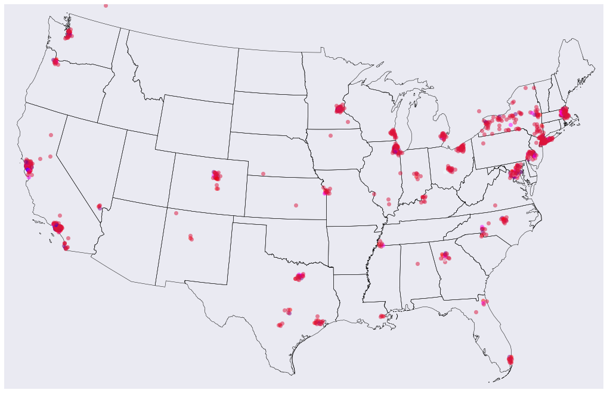

```python
plt.figure(figsize=(18,12))
# plt.subplots_adjust(left=0.05,right=0.95,top=0.90,bottom=0.05,wspace=0.15,hspace=0.05)
axs = plt.subplot(111)

m = Basemap(
llcrnrlon = -119, llcrnrlat = 22, urcrnrlon = -64,
urcrnrlat = 49, projection = 'lcc', lat_1 = 33,
lat_2 = 45, lon_0 = -95)

m.readshapefile('st99_d00', name='states', drawbounds=True)

# m = Basemap(llcrnrlon = -119, llcrnrlat = 22, urcrnrlon = -64,
# urcrnrlat = 49, projection = 'lcc', lat_1 = 33,
# lat_2 = 45, lon_0 = -95, ax = axs)

# m.drawcountries(linewidth=0.5)
# m.drawcoastlines(linewidth=0.5)
# m.fillcontinents(color="grey")
# m.drawmapboundary()

for idx, point in city_list2.iterrows():
    x,y = m(point['lon'],point['lat'])
    if point['ds_ratio'] == 0.0:
        color = 'crimson'
    elif point['ds_ratio'] > 0.0 and point['ds_ratio'] <= 0.2:
        color = 'red'
    elif point['ds_ratio'] > 0.2 and point['ds_ratio'] <= 0.4:
        color = 'purple'
    elif point['ds_ratio'] > 0.4 and point['ds_ratio'] <= 0.6:
        color = 'fuchsia'
    elif point['ds_ratio'] > 0.6 and point['ds_ratio'] <= 0.8:
        color = 'azure'
    elif point['ds_ratio'] > 0.8 and point['ds_ratio'] <= 1.0:
        color = 'blue'
    else:
        color = "red"
    axs.plot(x,y,marker='o',alpha=.5,c=color)

plt.show()
```

#### Top Locations by Category

If we take a look at jobs across job categories and locations, we see that New York, Chicago, San Francisco and Seattle are the top spots for both data science and MBA jobs.

```python
ds_job_locs = pd.DataFrame((df_data_sci
     .groupby('Location')
     .count()
     .sort_values('Company',ascending=False)['Company']
     .reset_index()))
mba_job_locs = pd.DataFrame((df_mba
     .groupby('Location')
     .count()
     .sort_values('Company',ascending=False)['Company']
     .reset_index()))
combined_locs = pd.concat([mba_job_locs, ds_job_locs], axis=1)
combined_locs.columns = ['MBA_Locations','Job_Counts',
                         'DS_Locations','Job_Counts']
```

```python
combined_locs.head(20)
```

|  | MBA_Locations | Job_Counts | DS_Locations | Job_Counts |
| --- | --- | --- | --- | --- |
| 0 | New York, NY | 3008 | New York, NY | 1578.0 |
| 1 | Chicago, IL | 1639 | San Francisco, CA | 1291.0 |
| 2 | San Francisco, CA | 1620 | Chicago, IL | 615.0 |
| 3 | Seattle, WA | 1516 | Seattle, WA | 562.0 |
| 4 | Los Angeles, CA | 977 | Boston, MA | 498.0 |
| 5 | Houston, TX | 963 | Austin, TX | 437.0 |
| 6 | Boston, MA | 931 | Washington, DC | 344.0 |
| 7 | Austin, TX | 681 | Houston, TX | 333.0 |
| 8 | Washington, DC | 672 | Los Angeles, CA | 324.0 |
| 9 | Atlanta, GA | 528 | Atlanta, GA | 258.0 |
| 10 | Denver, CO | 454 | San Diego, CA | 226.0 |
| 11 | Charlotte, NC | 415 | Denver, CO | 222.0 |
| 12 | Portland, OR | 348 | Redmond, WA | 202.0 |
| 13 | Dallas, TX | 330 | Charlotte, NC | 185.0 |
| 14 | San Diego, CA | 322 | McLean, VA | 170.0 |
| 15 | Cambridge, MA | 290 | Cambridge, MA | 169.0 |
| 16 | Redmond, WA | 287 | San Antonio, TX | 167.0 |
| 17 | Philadelphia, PA | 285 | Philadelphia, PA | 160.0 |
| 18 | Bellevue, WA | 267 | Jacksonville, FL | 156.0 |
| 19 | Indianapolis, IN | 261 | Columbus, OH | 155.0 |

#### Top Location Category Ratios

Cities with the highest proprtions of MBA/Data Science jobs are: Houston, Los Angeles, Seattle and Chicago.

```python
city_list_ratio = pd.DataFrame(df_combined
                               .groupby(['Location','category'])
                               .size()).reset_index().sort_values(0,ascending=False)
city_list_totals = city_list_ratio.groupby("Location").agg({0:np.sum})
city_list_totals['Location'] = city_list_totals.index
city_list_ratio = city_list_ratio.merge(city_list_totals,how="inner",on="Location")
city_list_ratio.columns = ["Location","category","cat_count","tot_count"]
city_list_ratio['cat_pct'] = city_list_ratio['cat_count']/city_list_ratio['tot_count']
city_list_ratio = city_list_ratio.sort_values(['tot_count','Location','category'],ascending=False)
city_list_ratio = city_list_ratio.head(50)
city_list_ratio.head(20)
```

|  | Location | category | cat_count | tot_count | cat_pct |
| --- | --- | --- | --- | --- | --- |
| 0 | New York, NY | mba | 3010 | 4591 | 0.655631 |
| 1 | New York, NY | data_science | 1581 | 4591 | 0.344369 |
| 4 | San Francisco, CA | mba | 1620 | 2915 | 0.555746 |
| 5 | San Francisco, CA | data_science | 1295 | 2915 | 0.444254 |
| 2 | Chicago, IL | mba | 1640 | 2255 | 0.727273 |
| 3 | Chicago, IL | data_science | 615 | 2255 | 0.272727 |
| 6 | Seattle, WA | mba | 1516 | 2078 | 0.729548 |
| 7 | Seattle, WA | data_science | 562 | 2078 | 0.270452 |
| 12 | Boston, MA | mba | 933 | 1431 | 0.651992 |
| 13 | Boston, MA | data_science | 498 | 1431 | 0.348008 |
| 8 | Los Angeles, CA | mba | 977 | 1301 | 0.750961 |
| 9 | Los Angeles, CA | data_science | 324 | 1301 | 0.249039 |
| 10 | Houston, TX | mba | 967 | 1301 | 0.743274 |
| 11 | Houston, TX | data_science | 334 | 1301 | 0.256726 |
| 14 | Austin, TX | mba | 681 | 1118 | 0.609123 |
| 15 | Austin, TX | data_science | 437 | 1118 | 0.390877 |
| 16 | Washington, DC | mba | 672 | 1016 | 0.661417 |
| 17 | Washington, DC | data_science | 344 | 1016 | 0.338583 |
| 18 | Atlanta, GA | mba | 528 | 786 | 0.671756 |
| 19 | Atlanta, GA | data_science | 258 | 786 | 0.328244 |

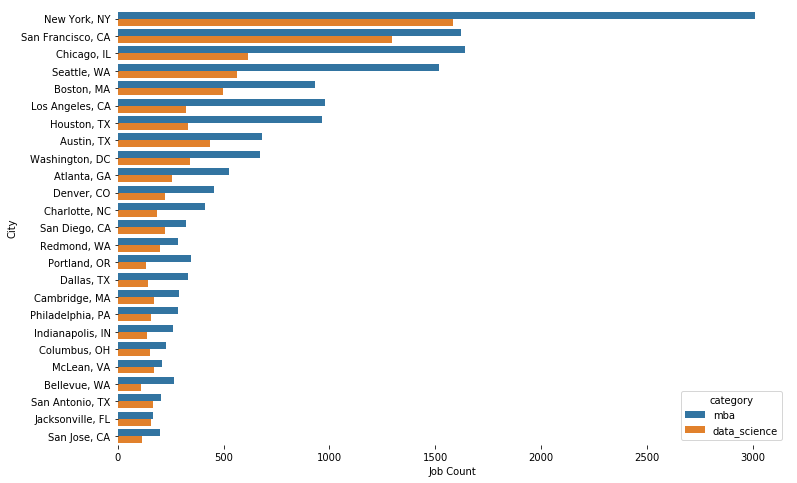

```python
import seaborn as sns
%matplotlib inline
fig, ax1 = plt.subplots(figsize=(12, 8))
sns.barplot(y='Location', x='cat_count', hue="category", data=city_list_ratio, ax=ax1,linewidth=2.5);
sns.despine(left=True, bottom=True)
ax1.set(xlabel='Job Count', ylabel='City');
```

### Company Trends

#### Top Companies by City

##### Data Science

```python
# group by city, company and create company ranks based on number of jobs
ds_top_company_by_city = pd.DataFrame(df_data_sci.groupby(['Location','Company']).size().reset_index())
ds_top_company_by_city.columns = ['Location','Company','Count']
ds_top_company_by_city.sort_values(['Location','Count'],ascending=False,inplace=True)
ds_top_company_by_city['company_rank'] = ds_top_company_by_city.groupby('Location')['Count'].rank(method='first',ascending=False).astype(int)
# group by city and create city ranks based on number of jobs
city_ranks = pd.DataFrame(df_data_sci.groupby('Location').size().rank(method='first',ascending=False).astype(int).reset_index())
city_ranks.columns = ['Location','city_rank']
ds_top_company_by_city = pd.merge(ds_top_company_by_city,city_ranks,how="inner",on="Location")
ds_top_company_by_city.sort_values(['city_rank','company_rank'],inplace=True)
```

```python
ds_top_company_by_city.groupby('Location').head()[:50]
```

|  | Location | Company | Count | company_rank | city_rank |
| --- | --- | --- | --- | --- | --- |
| 2309 | New York, NY | Averity | 77 | 1 | 1 |
| 2310 | New York, NY | JP Morgan Chase | 68 | 2 | 1 |
| 2311 | New York, NY | Integral Ad Science | 53 | 3 | 1 |
| 2312 | New York, NY | Essence | 24 | 4 | 1 |
| 2313 | New York, NY | KPMG | 24 | 5 | 1 |
| 916 | San Francisco, CA | Uber | 35 | 1 | 2 |
| 917 | San Francisco, CA | Salesforce | 34 | 2 | 2 |
| 918 | San Francisco, CA | SigFig | 30 | 3 | 2 |
| 919 | San Francisco, CA | CrowdFlower | 29 | 4 | 2 |
| 920 | San Francisco, CA | Ancestry | 25 | 5 | 2 |
| 5461 | Chicago, IL | University of Chicago | 40 | 1 | 3 |
| 5462 | Chicago, IL | Jobspring Partners | 19 | 2 | 3 |
| 5463 | Chicago, IL | KPMG | 17 | 3 | 3 |
| 5464 | Chicago, IL | AllianceData | 13 | 4 | 3 |
| 5465 | Chicago, IL | Blue Cross Blue Shield of IL, MT, NM, OK & TX | 12 | 5 | 3 |
| 542 | Seattle, WA | Amazon Corporate LLC | 177 | 1 | 4 |
| 543 | Seattle, WA | Amazon Web Services, Inc. | 17 | 2 | 4 |
| 544 | Seattle, WA | Textio | 17 | 3 | 4 |
| 545 | Seattle, WA | Nordstrom | 14 | 4 | 4 |
| 546 | Seattle, WA | Fred Hutchinson Cancer Research Center | 12 | 5 | 4 |
| 6113 | Boston, MA | Wayfair | 43 | 1 | 5 |
| 6114 | Boston, MA | DataXu | 32 | 2 | 5 |
| 6115 | Boston, MA | Liberty Mutual | 25 | 3 | 5 |
| 6116 | Boston, MA | DataRobot | 18 | 4 | 5 |
| 6117 | Boston, MA | Partners HealthCare(PHS) | 12 | 5 | 5 |
| 6486 | Austin, TX | HomeAway | 23 | 1 | 6 |
| 6487 | Austin, TX | Indeed | 16 | 2 | 6 |
| 6488 | Austin, TX | Civitas Learning | 15 | 3 | 6 |
| 6489 | Austin, TX | Iodine Software | 14 | 4 | 6 |
| 6490 | Austin, TX | MAP Health Management | 13 | 5 | 6 |
| 115 | Washington, DC | Altamira Technologies Corporation | 48 | 1 | 7 |
| 116 | Washington, DC | Booz Allen Hamilton | 33 | 2 | 7 |
| 117 | Washington, DC | Jobspring Partners | 16 | 3 | 7 |
| 118 | Washington, DC | Central Intelligence Agency | 9 | 4 | 7 |
| 119 | Washington, DC | The Upside Travel Company, LLC | 9 | 5 | 7 |
| 4313 | Houston, TX | Pros. | 49 | 1 | 8 |
| 4314 | Houston, TX | Halliburton | 12 | 2 | 8 |
| 4315 | Houston, TX | UT Health Science Center at Houston | 10 | 3 | 8 |
| 4316 | Houston, TX | General Electric | 9 | 4 | 8 |
| 4317 | Houston, TX | Baylor College of Medicine | 5 | 5 | 8 |
| 3626 | Los Angeles, CA | Omaze | 24 | 1 | 9 |
| 3627 | Los Angeles, CA | ZestFinance | 17 | 2 | 9 |
| 3628 | Los Angeles, CA | UCLA | 13 | 3 | 9 |
| 3629 | Los Angeles, CA | Netflix | 12 | 4 | 9 |
| 3630 | Los Angeles, CA | LT | 11 | 5 | 9 |
| 6693 | Atlanta, GA | Pindrop | 21 | 1 | 10 |
| 6694 | Atlanta, GA | Capgemini | 19 | 2 | 10 |
| 6695 | Atlanta, GA | CocaCola | 13 | 3 | 10 |
| 6696 | Atlanta, GA | KPMG | 11 | 4 | 10 |
| 6697 | Atlanta, GA | Turner | 10 | 5 | 10 |

##### MBA

```python
# group by city, company and create company ranks based on number of jobs
mba_top_company_by_city = pd.DataFrame(df_mba.groupby(['Location','Company']).size().reset_index())
mba_top_company_by_city.columns = ['Location','Company','Count']
mba_top_company_by_city.sort_values(['Location','Count'],ascending=False,inplace=True)
mba_top_company_by_city['company_rank'] = mba_top_company_by_city.groupby('Location')['Count'].rank(method='first',ascending=False).astype(int)
# group by city and create city ranks based on number of jobs
city_ranks = pd.DataFrame(df_mba.groupby('Location').size().rank(method='first',ascending=False).astype(int).reset_index())
city_ranks.columns = ['Location','city_rank']
mba_top_company_by_city = pd.merge(mba_top_company_by_city,city_ranks,how="inner",on="Location")
mba_top_company_by_city.sort_values(['city_rank','company_rank'],inplace=True)
```

```python
mba_top_company_by_city.groupby('Location').head()[:50]
```

|  | Location | Company | Count | company_rank | city_rank |
| --- | --- | --- | --- | --- | --- |
| 4338 | New York, NY | JP Morgan Chase | 93 | 1 | 1 |
| 4339 | New York, NY | Michael Page US | 60 | 2 | 1 |
| 4340 | New York, NY | American Express | 54 | 3 | 1 |
| 4341 | New York, NY | BNY Mellon | 44 | 4 | 1 |
| 4342 | New York, NY | EY | 43 | 5 | 1 |
| 10081 | Chicago, IL | University of Chicago | 67 | 1 | 2 |
| 10082 | Chicago, IL | United Airlines Inc. | 52 | 2 | 2 |
| 10083 | Chicago, IL | KPMG | 28 | 3 | 2 |
| 10084 | Chicago, IL | BMO Financial Group | 26 | 4 | 2 |
| 10085 | Chicago, IL | JP Morgan Chase | 24 | 5 | 2 |
| 1886 | San Francisco, CA | Salesforce | 46 | 1 | 3 |
| 1887 | San Francisco, CA | Wells Fargo | 43 | 2 | 3 |
| 1888 | San Francisco, CA | University of California San Francisco | 26 | 3 | 3 |
| 1889 | San Francisco, CA | Charles Schwab | 25 | 4 | 3 |
| 1890 | San Francisco, CA | Robert Walters | 24 | 5 | 3 |
| 1237 | Seattle, WA | Amazon Corporate LLC | 728 | 1 | 4 |
| 1238 | Seattle, WA | Amazon Web Services, Inc. | 108 | 2 | 4 |
| 1239 | Seattle, WA | Oracle | 30 | 3 | 4 |
| 1240 | Seattle, WA | Amazon Services, LLC | 26 | 4 | 4 |
| 1241 | Seattle, WA | Starbucks | 20 | 5 | 4 |
| 6427 | Los Angeles, CA | Deloitte | 55 | 1 | 5 |
| 6428 | Los Angeles, CA | UCLA | 28 | 2 | 5 |
| 6429 | Los Angeles, CA | Century Group | 24 | 3 | 5 |
| 6430 | Los Angeles, CA | Capital Group | 20 | 4 | 5 |
| 6431 | Los Angeles, CA | USC | 20 | 5 | 5 |
| 7702 | Houston, TX | Emerson | 54 | 1 | 6 |
| 7703 | Houston, TX | Houston Methodist | 27 | 2 | 6 |
| 7704 | Houston, TX | Rice University | 18 | 3 | 6 |
| 7705 | Houston, TX | HP | 17 | 4 | 6 |
| 7706 | Houston, TX | Hewlett Packard Enterprise | 17 | 5 | 6 |
| 11470 | Boston, MA | Wayfair | 70 | 1 | 7 |
| 11471 | Boston, MA | State Street | 61 | 2 | 7 |
| 11472 | Boston, MA | Liberty Mutual | 30 | 3 | 7 |
| 11473 | Boston, MA | WinterWyman | 17 | 4 | 7 |
| 11474 | Boston, MA | Michael Page US | 15 | 5 | 7 |
| 12237 | Austin, TX | Emerson | 21 | 1 | 8 |
| 12238 | Austin, TX | Vista Equity Partners | 20 | 2 | 8 |
| 12239 | Austin, TX | Dell | 19 | 3 | 8 |
| 12240 | Austin, TX | Visa | 17 | 4 | 8 |
| 12241 | Austin, TX | HomeAway | 15 | 5 | 8 |
| 285 | Washington, DC | Booz Allen Hamilton | 38 | 1 | 9 |
| 286 | Washington, DC | Arc Aspicio | 22 | 2 | 9 |
| 287 | Washington, DC | MBA CSi | 21 | 3 | 9 |
| 288 | Washington, DC | Deloitte | 17 | 4 | 9 |
| 289 | Washington, DC | Medstar Georgetown University Hospital | 17 | 5 | 9 |
| 12588 | Atlanta, GA | SunTrust | 43 | 1 | 10 |
| 12589 | Atlanta, GA | CocaCola | 30 | 2 | 10 |
| 12590 | Atlanta, GA | Home Depot | 21 | 3 | 10 |
| 12591 | Atlanta, GA | Fidelis Search | 20 | 4 | 10 |
| 12592 | Atlanta, GA | Global Payments | 16 | 5 | 10 |

#### Top Companies by Category

```python
ds_job_comps = pd.DataFrame((df_data_sci
     .groupby('Company')
     .count()
     .sort_values('Location',ascending=False)['Location']
     .reset_index()))
mba_job_comps = pd.DataFrame((df_mba
     .groupby('Company')
     .count()
     .sort_values('Location',ascending=False)['Location']
     .reset_index()))
combined_comps = pd.concat([mba_job_comps, ds_job_comps], axis=1)
combined_comps.columns = ['MBA_Companies','Job_Counts',
                         'DS_Companies','Job_Counts']
```

```python
combined_comps.head(20)
```

|  | MBA_Companies | Job_Counts | DS_Companies | Job_Counts |
| --- | --- | --- | --- | --- |
| 0 | Amazon Corporate LLC | 761 | Amazon Corporate LLC | 227.0 |
| 1 | Microsoft | 322 | Microsoft | 216.0 |
| 2 | JP Morgan Chase | 268 | Booz Allen Hamilton | 119.0 |
| 3 | Emerson | 255 | JP Morgan Chase | 113.0 |
| 4 | Michael Page US | 211 | KPMG | 104.0 |
| 5 | Wells Fargo | 182 | Averity | 83.0 |
| 6 | Bank of America | 169 | Workbridge Associates | 74.0 |
| 7 | Amazon Web Services, Inc. | 159 | Altamira Technologies Corporation | 74.0 |
| 8 | Google | 145 | Integral Ad Science | 71.0 |
| 9 | CBRE | 142 | Jobspring Partners | 70.0 |
| 10 | Citi | 123 | Leidos | 63.0 |
| 11 | Deloitte | 118 | Comcast | 61.0 |
| 12 | Macy's | 117 | IBM | 54.0 |
| 13 | Aramark | 109 | Oracle | 53.0 |
| 14 | Parker and Lynch | 106 | Cleveland Clinic | 52.0 |
| 15 | KPMG | 105 | Pros. | 51.0 |
| 16 | Visa | 105 | Northrop Grumman | 50.0 |
| 17 | Anthem, Inc. | 103 | Sandia National Laboratories | 49.0 |
| 18 | Booz Allen Hamilton | 101 | Capital One | 48.0 |
| 19 | Oracle | 97 | AllianceData | 46.0 |

#### Top Company Category Ratios

Among our top hirers, Booz Allen Hamilton and KPMG have near even splits between MBA and Data Science positions.

```python
company_list_ratio = pd.DataFrame(df_combined
                               .groupby(['Company','category'])
                               .size()).reset_index().sort_values(0,ascending=False)
company_list_totals = company_list_ratio.groupby("Company").agg({0:np.sum})
company_list_totals['Company'] = company_list_totals.index
company_list_ratio = company_list_ratio.merge(company_list_totals,how="inner",on="Company")
company_list_ratio.columns = ["Company","category","cat_count","tot_count"]
company_list_ratio['cat_pct'] = company_list_ratio['cat_count']/company_list_ratio['tot_count']
company_list_ratio = company_list_ratio.sort_values(['tot_count','Company','category'],ascending=False)
company_list_ratio = company_list_ratio.head(50)
company_list_ratio.head(20)
```

|  | Company | category | cat_count | tot_count | cat_pct |
| --- | --- | --- | --- | --- | --- |
| 0 | Amazon Corporate LLC | mba | 761 | 988 | 0.770243 |
| 1 | Amazon Corporate LLC | data_science | 227 | 988 | 0.229757 |
| 2 | Microsoft | mba | 322 | 538 | 0.598513 |
| 3 | Microsoft | data_science | 216 | 538 | 0.401487 |
| 4 | JP Morgan Chase | mba | 268 | 381 | 0.703412 |
| 5 | JP Morgan Chase | data_science | 113 | 381 | 0.296588 |
| 6 | Emerson | mba | 255 | 258 | 0.988372 |
| 7 | Emerson | data_science | 3 | 258 | 0.011628 |
| 23 | Booz Allen Hamilton | mba | 101 | 220 | 0.459091 |
| 22 | Booz Allen Hamilton | data_science | 119 | 220 | 0.540909 |
| 10 | Wells Fargo | mba | 182 | 213 | 0.854460 |
| 11 | Wells Fargo | data_science | 31 | 213 | 0.145540 |
| 8 | Michael Page US | mba | 211 | 212 | 0.995283 |
| 9 | Michael Page US | data_science | 1 | 212 | 0.004717 |
| 31 | KPMG | mba | 105 | 209 | 0.502392 |
| 32 | KPMG | data_science | 104 | 209 | 0.497608 |
| 12 | Bank of America | mba | 169 | 196 | 0.862245 |
| 13 | Bank of America | data_science | 27 | 196 | 0.137755 |
| 14 | Amazon Web Services, Inc. | mba | 159 | 194 | 0.819588 |
| 15 | Amazon Web Services, Inc. | data_science | 35 | 194 | 0.180412 |

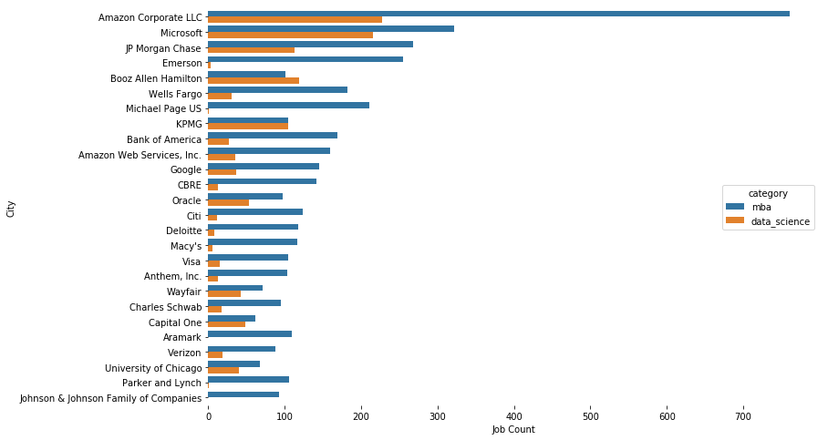

```python
import seaborn as sns
%matplotlib inline
fig, ax1 = plt.subplots(figsize=(12, 8))
sns.barplot(y='Company', x='cat_count', hue="category", data=company_list_ratio, ax=ax1,linewidth=2.5);
sns.despine(left=True, bottom=True)
ax1.set(xlabel='Job Count', ylabel='City');
```

### Job Titles

Looking at the top job titles by job category, there seems to be less diversity for data science titles than mba titles. We see that "product manager" is common across both categories.

```python
ds_job_titles = pd.DataFrame((df_data_sci
     .groupby('Job_Title')
     .count()
     .sort_values('Company',ascending=False)['Company']
     .head(20).reset_index()))
mba_job_titles = pd.DataFrame((df_mba
     .groupby('Job_Title')
     .count()
     .sort_values('Company',ascending=False)['Company']
     .head(20).reset_index()))
combined_titles = pd.concat([mba_job_titles,ds_job_titles], axis=1)
combined_titles.columns = ['MBA_Titles','Job_Counts',
                         'DS_Titles','Job_Counts']
```

```python
combined_titles
```

|  | MBA_Titles | Job_Counts | DS_Titles | Job_Counts |
| --- | --- | --- | --- | --- |
| 0 | Senior Financial Analyst | 220 | Data Scientist | 589 |
| 1 | Financial Analyst | 213 | Senior Data Scientist | 152 |
| 2 | Product Manager | 202 | Data Engineer | 116 |
| 3 | Controller | 178 | Software Engineer | 108 |
| 4 | Finance Manager | 131 | Data Analyst | 107 |
| 5 | Project Manager | 116 | Senior Software Engineer | 88 |
| 6 | Senior Accountant | 116 | Product Manager | 47 |
| 7 | Product Marketing Manager | 102 | Senior Data Engineer | 43 |
| 8 | Senior Product Manager | 85 | Sr. Data Scientist | 41 |
| 9 | Chief Financial Officer | 84 | Retail Customer Service Associate | 41 |
| 10 | Marketing Manager | 80 | Principal Data Scientist | 39 |
| 11 | Program Manager | 80 | Software Development Engineer | 36 |
| 12 | Director of Finance | 74 | Director of Data Science | 35 |
| 13 | Accounting Manager | 68 | Business Analyst | 31 |
| 14 | Business Analyst | 65 | Lead Data Scientist | 29 |
| 15 | Sr. Financial Analyst | 65 | Data Science Engineer | 29 |
| 16 | Business Development Manager | 65 | Senior Product Manager | 28 |
| 17 | Senior Product Marketing Manager | 56 | Software Developer | 27 |
| 18 | Staff Accountant | 51 | Data Science Manager | 27 |
| 19 | Sr. Product Manager | 47 | Director, Data Science | 27 |

#### Top Titles by City

##### Data Science

```python
# group by city, company and create company ranks based on number of jobs
ds_top_title_by_city = pd.DataFrame(df_data_sci.groupby(['Location','Job_Title']).size().reset_index())
ds_top_title_by_city.columns = ['Location','Title','Count']
ds_top_title_by_city.sort_values(['Location','Count'],ascending=False,inplace=True)
ds_top_title_by_city['title_rank'] = ds_top_title_by_city.groupby('Location')['Count'].rank(method='first',ascending=False).astype(int)
# group by city and create city ranks based on number of jobs
city_ranks = pd.DataFrame(df_data_sci.groupby('Location').size().rank(method='first',ascending=False).astype(int).reset_index())
city_ranks.columns = ['Location','city_rank']
ds_top_title_by_city = pd.merge(ds_top_title_by_city,city_ranks,how="inner",on="Location")
ds_top_title_by_city.sort_values(['city_rank','title_rank'],inplace=True)
```

```python
ds_top_title_by_city.groupby('Location').head()[:50]
```

|  | Location | Title | Count | title_rank | city_rank |
| --- | --- | --- | --- | --- | --- |
| 4111 | New York, NY | Data Scientist | 97 | 1 | 1 |
| 4112 | New York, NY | Senior Data Scientist | 30 | 2 | 1 |
| 4113 | New York, NY | Data Engineer | 15 | 3 | 1 |
| 4114 | New York, NY | Data Analyst | 12 | 4 | 1 |
| 4115 | New York, NY | Product Manager | 12 | 5 | 1 |
| 1677 | San Francisco, CA | Data Scientist | 65 | 1 | 2 |
| 1678 | San Francisco, CA | Data Engineer | 22 | 2 | 2 |
| 1679 | San Francisco, CA | Data Analyst | 21 | 3 | 2 |
| 1680 | San Francisco, CA | Senior Data Scientist | 18 | 4 | 2 |
| 1681 | San Francisco, CA | Backend Engineer (MS1) | 15 | 5 | 2 |
| 9258 | Chicago, IL | Data Scientist | 32 | 1 | 3 |
| 9259 | Chicago, IL | Data Engineer | 12 | 2 | 3 |
| 9260 | Chicago, IL | Software Engineer | 7 | 3 | 3 |
| 9261 | Chicago, IL | Senior Software Engineer | 6 | 4 | 3 |
| 9262 | Chicago, IL | Sr Data Scientist | 6 | 5 | 3 |
| 895 | Seattle, WA | Software Development Engineer | 18 | 1 | 4 |
| 896 | Seattle, WA | Data Science Manager | 11 | 2 | 4 |
| 897 | Seattle, WA | Data Scientist | 11 | 3 | 4 |
| 898 | Seattle, WA | Business Intelligence Engineer | 7 | 4 | 4 |
| 899 | Seattle, WA | Senior Data Scientist | 6 | 5 | 4 |
| 10321 | Boston, MA | Data Scientist | 25 | 1 | 5 |
| 10322 | Boston, MA | Senior Quantitative Analyst-Predictive Modeling | 5 | 2 | 5 |
| 10323 | Boston, MA | Data Engineer | 4 | 3 | 5 |
| 10324 | Boston, MA | Data Scientist / Quantitative Analyst | 4 | 4 | 5 |
| 10325 | Boston, MA | Senior Software Engineer | 4 | 5 | 5 |
| 11055 | Austin, TX | Data Scientist | 29 | 1 | 6 |
| 11056 | Austin, TX | Data Engineer | 8 | 2 | 6 |
| 11057 | Austin, TX | Senior Software Engineer | 8 | 3 | 6 |
| 11058 | Austin, TX | Data Analyst | 6 | 4 | 6 |
| 11059 | Austin, TX | Solution Engineer - Austin, Texas | 6 | 5 | 6 |
| 185 | Washington, DC | Data Scientist | 26 | 1 | 7 |
| 186 | Washington, DC | Senior Data Scientist | 6 | 2 | 7 |
| 187 | Washington, DC | Data Analyst | 5 | 3 | 7 |
| 188 | Washington, DC | Senior Software Engineer - Public Sector | 4 | 4 | 7 |
| 189 | Washington, DC | Data Lead/PM | 3 | 5 | 7 |
| 7431 | Houston, TX | Data Scientist | 17 | 1 | 8 |
| 7432 | Houston, TX | Data Science Specialist | 4 | 2 | 8 |
| 7433 | Houston, TX | Offline Optimization Engineer (BS/MS/PhD) | 4 | 3 | 8 |
| 7434 | Houston, TX | Assistant/Associate Professor-The Center for P... | 3 | 4 | 8 |
| 7435 | Houston, TX | Data Analyst/Scientist | 3 | 5 | 8 |
| 6393 | Los Angeles, CA | Data Scientist | 9 | 1 | 9 |
| 6394 | Los Angeles, CA | Data and Systems Manager | 6 | 2 | 9 |
| 6395 | Los Angeles, CA | Senior Data Scientist | 6 | 3 | 9 |
| 6396 | Los Angeles, CA | Sales Engineer | 5 | 4 | 9 |
| 6397 | Los Angeles, CA | Data Analyst | 4 | 5 | 9 |
| 11402 | Atlanta, GA | Data Scientist | 7 | 1 | 10 |
| 11403 | Atlanta, GA | Senior Data Scientist | 4 | 2 | 10 |
| 11404 | Atlanta, GA | ETL Data Analyst | 3 | 3 | 10 |
| 11405 | Atlanta, GA | Software Engineer, Data Engineering | 3 | 4 | 10 |
| 11406 | Atlanta, GA | Cloud Platform Engineer | 2 | 5 | 10 |

##### MBA

```python
# group by city, company and create company ranks based on number of jobs
mba_top_title_by_city = pd.DataFrame(df_mba.groupby(['Location','Job_Title']).size().reset_index())
mba_top_title_by_city.columns = ['Location','Title','Count']
mba_top_title_by_city.sort_values(['Location','Count'],ascending=False,inplace=True)
mba_top_title_by_city['title_rank'] = mba_top_title_by_city.groupby('Location')['Count'].rank(method='first',ascending=False).astype(int)
# group by city and create city ranks based on number of jobs
city_ranks = pd.DataFrame(df_mba.groupby('Location').size().rank(method='first',ascending=False).astype(int).reset_index())
city_ranks.columns = ['Location','city_rank']
mba_top_title_by_city = pd.merge(mba_top_title_by_city,city_ranks,how="inner",on="Location")
mba_top_title_by_city.sort_values(['city_rank','title_rank'],inplace=True)
```

```python
mba_top_title_by_city.groupby('Location').head()[:50]
```

|  | Location | Title | Count | title_rank | city_rank |
| --- | --- | --- | --- | --- | --- |
| 8244 | New York, NY | Senior Financial Analyst | 18 | 1 | 1 |
| 8245 | New York, NY | Financial Analyst | 13 | 2 | 1 |
| 8246 | New York, NY | Product Manager | 12 | 3 | 1 |
| 8247 | New York, NY | Project Manager | 12 | 4 | 1 |
| 8248 | New York, NY | Chief Financial Officer | 9 | 5 | 1 |
| 18413 | Chicago, IL | Senior Accountant | 10 | 1 | 2 |
| 18414 | Chicago, IL | Senior Financial Analyst | 10 | 2 | 2 |
| 18415 | Chicago, IL | Engagement Manager | 8 | 3 | 2 |
| 18416 | Chicago, IL | Brand Manager | 7 | 4 | 2 |
| 18417 | Chicago, IL | Product Manager | 7 | 5 | 2 |
| 3888 | San Francisco, CA | Product Manager | 22 | 1 | 3 |
| 3889 | San Francisco, CA | Senior Product Marketing Manager | 19 | 2 | 3 |
| 3890 | San Francisco, CA | Product Marketing Manager | 16 | 3 | 3 |
| 3891 | San Francisco, CA | Senior Product Manager | 10 | 4 | 3 |
| 3892 | San Francisco, CA | Product Marketing Director | 8 | 5 | 3 |
| 2100 | Seattle, WA | Sr. Product Manager | 18 | 1 | 4 |
| 2101 | Seattle, WA | Finance Manager | 14 | 2 | 4 |
| 2102 | Seattle, WA | Principal Product Manager | 13 | 3 | 4 |
| 2103 | Seattle, WA | Product Manager | 13 | 4 | 4 |
| 2104 | Seattle, WA | Senior Financial Analyst | 11 | 5 | 4 |
| 12501 | Los Angeles, CA | Controller | 17 | 1 | 5 |
| 12502 | Los Angeles, CA | Senior Financial Analyst | 7 | 2 | 5 |
| 12503 | Los Angeles, CA | Chief Financial Officer | 6 | 3 | 5 |
| 12504 | Los Angeles, CA | External ETF Wholesaler | 6 | 4 | 5 |
| 12505 | Los Angeles, CA | Senior Accountant | 6 | 5 | 5 |
| 14577 | Houston, TX | Financial Analyst | 16 | 1 | 6 |
| 14578 | Houston, TX | International Tax Manager | 15 | 2 | 6 |
| 14579 | Houston, TX | Performance Analyst | 15 | 3 | 6 |
| 14580 | Houston, TX | Site Director - Operations (Float) | 6 | 4 | 6 |
| 14581 | Houston, TX | Plant Manager | 5 | 5 | 6 |
| 21169 | Boston, MA | Senior Financial Analyst | 12 | 1 | 7 |
| 21170 | Boston, MA | Product Manager | 9 | 2 | 7 |
| 21171 | Boston, MA | Product Marketing Manager | 7 | 3 | 7 |
| 21172 | Boston, MA | Director, Business Development | 5 | 4 | 7 |
| 21173 | Boston, MA | Project Manager | 5 | 5 | 7 |
| 22685 | Austin, TX | Financial Analyst | 9 | 1 | 8 |
| 22686 | Austin, TX | Controller | 7 | 2 | 8 |
| 22687 | Austin, TX | Program Manager, Business Applications | 7 | 3 | 8 |
| 22688 | Austin, TX | Senior Financial Analyst | 7 | 4 | 8 |
| 22689 | Austin, TX | Management Consultant, Value Creation | 6 | 5 | 8 |
| 511 | Washington, DC | Data Quality Analyst | 7 | 1 | 9 |
| 512 | Washington, DC | Financial Analyst | 7 | 2 | 9 |
| 513 | Washington, DC | Senior Associate, Data Analytics and Consulting | 7 | 3 | 9 |
| 514 | Washington, DC | Director | 6 | 4 | 9 |
| 515 | Washington, DC | Project Manager | 5 | 5 | 9 |
| 23239 | Atlanta, GA | Sr Analyst, Finance - HPY Payment Processing | 16 | 1 | 10 |
| 23240 | Atlanta, GA | Senior Financial Analyst | 4 | 2 | 10 |
| 23241 | Atlanta, GA | FP&A Manager | 3 | 3 | 10 |
| 23242 | Atlanta, GA | Senior Staff Accountant | 3 | 4 | 10 |
| 23243 | Atlanta, GA | Senior Transaction Manager | 3 | 5 | 10 |

#### Top Titles by Company

##### Data Science

```python
# group by city, company and create company ranks based on number of jobs
ds_top_title_by_company = pd.DataFrame(df_data_sci.groupby(['Company','Job_Title']).size().reset_index())
ds_top_title_by_company.columns = ['Company','Title','Count']
ds_top_title_by_company.sort_values(['Company','Count'],ascending=False,inplace=True)
ds_top_title_by_company['title_rank'] = ds_top_title_by_company.groupby('Company')['Count'].rank(method='first',ascending=False).astype(int)
# group by city and create city ranks based on number of jobs
city_ranks = pd.DataFrame(df_data_sci.groupby('Company').size().rank(method='first',ascending=False).astype(int).reset_index())
city_ranks.columns = ['Company','company_rank']
ds_top_title_by_company = pd.merge(ds_top_title_by_company,city_ranks,how="inner",on="Company")
ds_top_title_by_company.sort_values(['company_rank','title_rank'],inplace=True)
```

```python
ds_top_title_by_company.groupby('Company').head()[:50]
```

|  | Company | Title | Count | title_rank | company_rank |
| --- | --- | --- | --- | --- | --- |
| 11851 | Amazon Corporate LLC | Software Development Engineer | 23 | 1 | 1 |
| 11852 | Amazon Corporate LLC | Business Intelligence Engineer | 6 | 2 | 1 |
| 11853 | Amazon Corporate LLC | Manager, Data Science | 5 | 3 | 1 |
| 11854 | Amazon Corporate LLC | Software Development Manager | 5 | 4 | 1 |
| 11855 | Amazon Corporate LLC | Sr. Product Manager | 4 | 5 | 1 |
| 5539 | Microsoft | Senior Software Engineer | 15 | 1 | 2 |
| 5540 | Microsoft | Software Engineer II | 15 | 2 | 2 |
| 5541 | Microsoft | Software Engineer | 12 | 3 | 2 |
| 5542 | Microsoft | Senior Program Manager | 9 | 4 | 2 |
| 5543 | Microsoft | Principal Software Engineer | 7 | 5 | 2 |
| 10857 | Booz Allen Hamilton | Data Scientist | 25 | 1 | 3 |
| 10858 | Booz Allen Hamilton | Data Scientist, Junior | 6 | 2 | 3 |
| 10859 | Booz Allen Hamilton | Data Scientist, Mid | 4 | 3 | 3 |
| 10860 | Booz Allen Hamilton | Cyber SME, Senior Manager | 3 | 4 | 3 |
| 10861 | Booz Allen Hamilton | SATCOM Solutions Engineer, Mid | 3 | 5 | 3 |
| 6900 | JP Morgan Chase | Commercial Banking - MMBSI Business Analysis -... | 9 | 1 | 4 |
| 6901 | JP Morgan Chase | Data Insights Associate - Intelligent Solutions | 4 | 2 | 4 |
| 6902 | JP Morgan Chase | CIB-Rapid Prototyping Data Scientist ? Vice Pr... | 3 | 3 | 4 |
| 6903 | JP Morgan Chase | CIB-Treasury Services, Accounts and Liquidity ... | 3 | 4 | 4 |
| 6904 | JP Morgan Chase | Corporate Finance - Estimations Design & Analy... | 3 | 5 | 4 |
| 6668 | KPMG | Senior Big Data Software Engineer - Big Data &... | 15 | 1 | 5 |
| 6669 | KPMG | Senior Big Data Software Engineer | 9 | 2 | 5 |
| 6670 | KPMG | Senior Associate, Strategic Profitability Insi... | 8 | 3 | 5 |
| 6671 | KPMG | Big Data Software Engineer Manager - Big Data ... | 6 | 4 | 5 |
| 6672 | KPMG | Director, Data Scientist | 5 | 5 | 5 |
| 11416 | Averity | Data Scientist for Global Digital Media Company | 4 | 1 | 6 |
| 11417 | Averity | Director of Data Science | 4 | 2 | 6 |
| 11418 | Averity | Director of Data Science, Analytics | 4 | 3 | 6 |
| 11419 | Averity | Data Scientist | 3 | 4 | 6 |
| 11420 | Averity | Senior Data Scientist for Multi-Billion Dollar... | 3 | 5 | 6 |
| 12034 | Altamira Technologies Corporation | Contracts Manager | 2 | 1 | 7 |
| 12035 | Altamira Technologies Corporation | Data Scientist | 2 | 2 | 7 |
| 12036 | Altamira Technologies Corporation | Analytic Model Developer ? Mid | 1 | 3 | 7 |
| 12037 | Altamira Technologies Corporation | Cloud Analytics Developer ? Mid | 1 | 4 | 7 |
| 12038 | Altamira Technologies Corporation | Cloud Analytics Developer ? Novice | 1 | 5 | 7 |
| 435 | Workbridge Associates | Data Engineer | 3 | 1 | 8 |
| 436 | Workbridge Associates | Data Scientist | 3 | 2 | 8 |
| 437 | Workbridge Associates | Senior Data Scientist | 3 | 3 | 8 |
| 438 | Workbridge Associates | Data Engineer Contractor | 2 | 4 | 8 |
| 439 | Workbridge Associates | Data Scientist (Java or Python) Contract | 2 | 5 | 8 |
| 7110 | Integral Ad Science | Client Services Manager | 7 | 1 | 9 |
| 7111 | Integral Ad Science | Account Manager - Programmatic | 4 | 2 | 9 |
| 7112 | Integral Ad Science | Senior Manager, Financial Planning & Analysis | 4 | 3 | 9 |
| 7113 | Integral Ad Science | Senior Software Engineer | 4 | 4 | 9 |
| 7114 | Integral Ad Science | Solutions Engineer | 4 | 5 | 9 |
| 6787 | Jobspring Partners | Data Engineer | 5 | 1 | 10 |
| 6788 | Jobspring Partners | Data Scientist | 4 | 2 | 10 |
| 6789 | Jobspring Partners | Senior Data Scientist | 3 | 3 | 10 |
| 6790 | Jobspring Partners | Contract Data Science | 2 | 4 | 10 |
| 6791 | Jobspring Partners | Data Analyst | 2 | 5 | 10 |

##### MBA

```python
# group by city, company and create company ranks based on number of jobs
mba_top_title_by_company = pd.DataFrame(df_mba.groupby(['Company','Job_Title']).size().reset_index())
mba_top_title_by_company.columns = ['Company','Title','Count']
mba_top_title_by_company.sort_values(['Company','Count'],ascending=False,inplace=True)
mba_top_title_by_company['title_rank'] = mba_top_title_by_company.groupby('Company')['Count'].rank(method='first',ascending=False).astype(int)
# group by city and create city ranks based on number of jobs
city_ranks = pd.DataFrame(df_mba.groupby('Company').size().rank(method='first',ascending=False).astype(int).reset_index())
city_ranks.columns = ['Company','company_rank']
mba_top_title_by_company = pd.merge(mba_top_title_by_company,city_ranks,how="inner",on="Company")
mba_top_title_by_company.sort_values(['company_rank','title_rank'],inplace=True)
```

```python
mba_top_title_by_company.groupby('Company').head()[:50]
```

|  | Company | Title | Count | title_rank | company_rank |
| --- | --- | --- | --- | --- | --- |
| 22766 | Amazon Corporate LLC | Sr. Product Manager | 15 | 1 | 1 |
| 22767 | Amazon Corporate LLC | Senior Financial Analyst | 11 | 2 | 1 |
| 22768 | Amazon Corporate LLC | Finance Manager | 9 | 3 | 1 |
| 22769 | Amazon Corporate LLC | Senior Product Manager | 8 | 4 | 1 |
| 22770 | Amazon Corporate LLC | Sr. Program Manager | 7 | 5 | 1 |
| 9627 | Microsoft | Principal Program Manager | 11 | 1 | 2 |
| 9628 | Microsoft | Ent Channel Mgr | 9 | 2 | 2 |
| 9629 | Microsoft | Senior Product Marketing Manager | 7 | 3 | 2 |
| 9630 | Microsoft | Business Program Manager | 6 | 4 | 2 |
| 9631 | Microsoft | Senior Program Manager | 6 | 5 | 2 |
| 12846 | JP Morgan Chase | Wealth Management - Private Bank - Client Advi... | 8 | 1 | 3 |
| 12847 | JP Morgan Chase | Consumer & Community Bank - Issue Validation -... | 6 | 2 | 3 |
| 12848 | JP Morgan Chase | Wealth Management - Advice Lab - Private Busin... | 4 | 3 | 3 |
| 12849 | JP Morgan Chase | Asset Management - Wealth Management - Private... | 3 | 4 | 3 |
| 12850 | JP Morgan Chase | Commercial Bank Risk - REB Portfolio Managemen... | 3 | 5 | 3 |
| 16579 | Emerson | Inside Sales Engineer | 6 | 1 | 4 |
| 16580 | Emerson | Order Mgmt Analyst | 3 | 2 | 4 |
| 16581 | Emerson | Pricing Specialist | 3 | 3 | 4 |
| 16582 | Emerson | Valve Technician | 3 | 4 | 4 |
| 16583 | Emerson | Assembler | 2 | 5 | 4 |
| 9881 | Michael Page US | Senior Financial Analyst | 6 | 1 | 5 |
| 9882 | Michael Page US | Senior Accountant | 4 | 2 | 5 |
| 9883 | Michael Page US | Assistant Controller | 3 | 3 | 5 |
| 9884 | Michael Page US | Controller | 3 | 4 | 5 |
| 9885 | Michael Page US | Financial Analyst | 3 | 5 | 5 |
| 832 | Wells Fargo | Private/Bus Ln Underwriter 4 | 9 | 1 | 6 |
| 833 | Wells Fargo | Strategic Sourcing Cons 2 | 9 | 2 | 6 |
| 834 | Wells Fargo | WM Regional Investment Mgr 2 | 8 | 3 | 6 |
| 835 | Wells Fargo | Business Systems Consultant 5 | 6 | 4 | 6 |
| 836 | Wells Fargo | WM Investment Strategy Spec | 6 | 5 | 6 |
| 21123 | Bank of America | Private Client Advisor II | 10 | 1 | 7 |
| 21124 | Bank of America | Leasing Credit Officer | 7 | 2 | 7 |
| 21125 | Bank of America | Sr. Relationship Manager | 6 | 3 | 7 |
| 21126 | Bank of America | Sr. Relationship Manager, Middle Market | 6 | 4 | 7 |
| 21127 | Bank of America | U.S. Trust Private Client Associate | 6 | 5 | 7 |
| 22536 | Amazon Web Services, Inc. | Advisory Consultant - Chicago | 2 | 1 | 8 |
| 22537 | Amazon Web Services, Inc. | Bus Dev and Analytics Manager | 2 | 2 | 8 |
| 22538 | Amazon Web Services, Inc. | Business Development Manager, AWS AI | 2 | 3 | 8 |
| 22539 | Amazon Web Services, Inc. | Cloud Technical Account Manager | 2 | 4 | 8 |
| 22540 | Amazon Web Services, Inc. | Digital Marketing Manager | 2 | 5 | 8 |
| 14896 | Google | Strategic Customer Engineer, Google Cloud | 7 | 1 | 9 |
| 14897 | Google | Technical Curriculum Developer, Google Cloud P... | 5 | 2 | 9 |
| 14898 | Google | Account Executive, Digital Advertising Sales | 4 | 3 | 9 |
| 14899 | Google | Product Manager - Google Cloud Platform | 4 | 4 | 9 |
| 14900 | Google | Sales Engineer Manager, Google Cloud | 4 | 5 | 9 |
| 20100 | CBRE | Senior Transaction Manager | 12 | 1 | 10 |
| 20101 | CBRE | Finance Manager | 9 | 2 | 10 |
| 20102 | CBRE | Finance Director | 8 | 3 | 10 |
| 20103 | CBRE | Loan Originator - Multifamily, Vice President | 8 | 4 | 10 |
| 20104 | CBRE | Senior Finance Manager | 8 | 5 | 10 |

# Pre-modeling steps

To train our final model:

- Begin by training individual models, fitted and tuned on the training set
- Combine individual models into an ensemble model, fitted and tuned on the validation set
- Evaluate final model performance on test set.

Before we can train our classification models, several steps need to be taken. The first of which is splitting our dataset into training & test sets. This is needed in order to determine that our model is not overfitting and classification performance can generalize to new data.

### Split into Training, Validation & Test sets

Lets combine our two datasets. We will also make 'mba' the positive class.

```python
# split into training & test sets
df_combined = df_mba_clean.append(df_data_sci_clean)
df_combined.drop_duplicates(subset='Job_Key',keep='last')
df_combined.reset_index(inplace=True)
df_combined['category'] = np.where(df_combined['category']=="mba",1,0)
```

```python
from sklearn.model_selection import train_test_split
X, X_test, y, y_test = train_test_split(df_combined['Snippet'],df_combined['category'],test_size=0.2,train_size=0.8,random_state=1)
X_train, X_cv, y_train, y_cv = train_test_split(X,y,test_size = 0.25,train_size =0.75,random_state=1)
```

```python
len(X_train)
```

```
31315
```

```python
len(y_train)
```

```
31315
```

```python
len(y_cv)
```

```
10439
```

```python
len(y_test)
```

```
10439
```

```python
# from sklearn.model_selection import train_test_split
# X_train, X_test, y_train, y_test = train_test_split(df_combined['Snippet'],
#                     df_combined['category'],
#                     test_size=0.2,random_state=1)
```

```python
#for later anlaysis (patterns)
# X_train_locations = df_combined.loc[X_train.index,"Location"]
# Y_train_locations = df_combined.loc[y_train.index,"Location"]
# X_train_companies = df_combined.loc[X_train.index,"Company"]
# Y_train_companies = df_combined.loc[y_train.index,"Company"]
# X_train_titles = df_combined.loc[X_train.index,"Job_Title"]
# Y_train_titles = df_combined.loc[y_train.index,"Job_Title"]
# X_train_category = df_combined.loc[X_train.index,"category"]
# Y_train_category = df_combined.loc[y_train.index,"category"]
```

# Model Techniques & Evaluation Metrics

We will also be following a somewhat uniform series of steps for executing the modeling phase, these techniques are used in order to maximize the performance of our specific models. While the various tuning parameters might vary from one model to the next, the below practices are widely applicable to most of the models we will train in the following sections.

### K-fold Cross-Validation

With k-fold cross validation, the training dataset is randomly split into k folds without replacement. K-1 folds are used for training the model while the kth fold is used for model testing. This process is then repeated k times.

K-fold cross validation is typically used for model tuning, or finding the optimal hyperparameter values that yield good model performance. Once this process is completed, we can then use those optimal hyperparameter values to train our model on the test set.

### Grid Search

A useful, brute force, technique in optimizing hyperparameters is called grid search. Grid search iterates though all specified combinations of hyperparameters for a given estimator or alogorithm, trains subsequent models on each and records the model's performance as given by a specified score, such as AUC (area under the curve) for classification problems or MSE (mean squared error) for prediction problems.

To choose hyperparameter values, as well as evaluate the quality of our models, we will look mainly at AUC.

### Performance Metrics

#### Confusion Matrices

Rows in the confusion matrix represent 'actual' classes, while columns represent 'predicted' classes. From a confusion matrix, we can derive the following performance metrics, which will inform us as to the specific strengths and shortcomings of our models.

We will define a function to create confusion matrices for our models as follows:

```python
def confusion_matrix(y_train,y_pred):
    import matplotlib.pyplot as plt
    from sklearn.metrics import confusion_matrix
    confmat = confusion_matrix(y_true=y_train, y_pred=y_pred)
    fix, ax = plt.subplots(figsize=(6,8))
    ax.matshow(confmat,cmap=plt.cm.Blues,alpha=0.3)
    for i in range(confmat.shape[0]):
        for j in range(confmat.shape[1]):
            ax.text(x=j,y=i,s=confmat[i,j],
                   va='center',ha='center',size=20)
    plt.xlabel('Predicted MBA')
    plt.ylabel('Actual MBA')
    plt.show()
```

#### Error and Accuracy

The prediction or classification error and accuracy give an overall picture of how many cases are misclassified by a given model.

- Error is the sum of all false predictions divided by the sum of total predictions

\begin{equation*} Error = \frac{FP+FN}{FP+FN+TP+TN} \end{equation*}

- Accuracy is the sum of all true predictions divided by the sum of total predictions

\begin{equation*} Accuracy = \frac{TP+TN}{FP+FN+TP+TN} \end{equation*}

#### True Positive Rate (TPR) and False Positive Rate (FPR)

These metrics are important for machine learning problems with imbalanced category proportions, such as this one where there are more MBA job listings than data science listings.

FPR is the ratio of negative samples that are incorrectly classified as positive or (1-TNR) where TNR (aka Specificity) is the ratio of negative samples that are incorrectly classified as negative.

\begin{equation*} FPR = \frac{FP}{N} + \frac{FP}{FP+TN} \end{equation*}

#### Precision and Recall

These metrics are related to TPR and FPR. The accuracy of the positive predictions is called 'Precision'. 'Recall', also called 'sensitivity' or the 'true positive rate' is the ratio of positive instances that are correctly detected by the classifier.

\begin{equation*} Precision = \frac{TP}{TP+FP} \end{equation*}

\begin{equation*} Recall = TPR = \frac{TP}{FN+TP} \end{equation*}

As a rule, a 'precision/recall tradeoff' exists, whereby increasing precision reduces recall and vice versa. This precision/recall curve can be visualized. We will define a function to generate such plots below:

```python
from sklearn.model_selection import cross_val_predict
y_scores = cross_val_predict(lr_clf,X_train,y_train,method='decision_function',n_jobs=1)
from sklearn.metrics import precision_recall_curve
y_train_bin = y_train
precisions,recalls,thresholds = precision_recall_curve(y_train_bin,y_scores)

def plot_precision_recall_vs_threshold(precisions,recalls,thresholds):
    plt.plot(thresholds,precisions[:-1],"b--",label="Precision")
    plt.plot(thresholds,recalls[:-1],"g--",label="Recall")
    plt.xlabel("Threshold")
    plt.legend(loc='upper left')
    plt.ylim([0,1])

plot_precision_recall_vs_threshold(precisions,recalls,thresholds)
plt.show()
```

[output not shown]

### F1 Score

F1 score is a combination of precision and recall and favors classes with similar precision and recall measures.

\begin{equation*} F1 = 2 * \frac{Precision * Recall}{Precision + Recall} \end{equation*}

### ROC Curve

The Receiver Operating Characeristic (ROC) curve is a useful tool for binary classification evaluation.

The ROC curve plots the true positive rate against the false positive rate or sensitivity (recall) versus 1-specificity.

Lets define another function to generate ROC Curves.

```python
from sklearn.metrics import roc_curve, auc, roc_auc_score
from sklearn.model_selection import cross_val_predict
# y_scores = cross_val_predict(lr_clf,X_train,y_train,cv=5)
# y_scores = cross_val_predict(lr_clf,X_train,y_train,cv=5,method='decision_function')

fpr,tpr,thresholds = roc_curve(y_train_bin,y_scores,pos_label=1)

def plot_roc_curve(fpr,tpr,label=None):
    plt.plot(fpr,tpr,linewidth=2,label=label)
    plt.plot([0,1],[0,1],'k--')
    plt.axis([0,1,0,1])
    plt.xlabel('False Positive Rate')
    plt.ylabel('True Positive Rate')
plot_roc_curve(fpr,tpr)
plt.show()
```

[output not shown]

# Training Classifiers

We are ready to begin training and tuning our classification models. As a reminder, our goal is to correctly classify as many job postings under their actual category (Data Science vs MBA).

We will train and tune the following types of classifiers:

- Logistic Regression Classifier
- K Nearest Neighbors Classifier
- Naive Bayes Classifier
- Support Vector Machine Classifier
- Stochastic Gradient Descent Classifier
- Random Forest Classifier

## Logistic Regression

**Logistic Regression** is a popular, easily implentable linear model classification technique that works with linearly separable data. Logistic Regression is a probabalistic model that uses a concept called an **odds ratio**. This ratio is the odds in favor of an instance belong to a particular class. Logistic regression takes the logarithm of the odds ratio to create the so-called **logit function** and then takes the inverse of the logit function to produce the **logistic function**. This function produces an output between 0 and 1 which can be interpreted as the probability of a particular observation or sample belonging to the predicted class. The probability threshold for determining which class is typically 50%, but this can be adjusted depending on the requirements of the problem.

**Regularization**

Regularization is the process of adding a penalty term to the cost function in order to yield smaller coefficient weights, in this way regularization introduces bias to the model. When employing regularization, the goal is to find the combination of coefficient weights that optimize the cost function of our model while simeltaneously allowing the model to generalize well on new data (bias-variance tradeoff). More generally, regularization is a tool we use to strike a balance between overfitting (high variance) and underfitting (high vias). In additional, regularization can also help combat multicolinearity among model features and filter out noise from data. With logistic regression, the cost function we are trying to **maximize** through regularization is called the **log-likelihood**.

**Hyperparameters explored:**

```
* Regularization penalty types:
    * L1 - Yields sparse feature vectors where most feature weights become zero.
    * L2 - Penalizes large individual coefficient weights, shrinking them towards zero.
* Inverse of Regularization Strength (C):
    * Decreased values of the inverse regularization parameter yields increased regularization strength.
```

```python
from sklearn.feature_extraction.text import CountVectorizer
from sklearn.feature_extraction.text import TfidfTransformer
from sklearn.linear_model import LogisticRegression
from sklearn.pipeline import Pipeline
from sklearn.model_selection import GridSearchCV
from sklearn.metrics import roc_curve, auc
```

```python
lr_clf = Pipeline([
                ('vect', CountVectorizer()),
                ('tfidf', TfidfTransformer()),
                ('clf', LogisticRegression(class_weight="balanced",
                                           n_jobs=-1,
                                           random_state=1,
                                           max_iter=1000,
                                          C=1,
                                          penalty='l2'))
])

# parameters = {'clf__penalty':['l1','l2'],
#               'clf__C': [0.001, 0.01, 0.1, 1, 10, 100, 1000]}

# lr_clf = GridSearchCV(lr_clf, param_grid=parameters, scoring='roc_auc',n_jobs=-1,cv=10,verbose=True)

# lr_clf.best_params_
# {'clf__C': 1, 'clf__penalty': 'l2'}

lr_clf.fit(X_train, y_train)
y_pred = lr_clf.predict(X_train)
```

```python
print('Train Accuracy: %.3f' % lr_clf.score(X_train, y_train))
```

```
Train Accuracy: 0.900
```

```python
np.mean(y_train==y_pred)
```

```
0.8998243653201341
```

#### Performance Metrics

```python
from sklearn import metrics
print(metrics.classification_report(y_train,y_pred))
```

```
             precision    recall  f1-score   support

          0       0.86      0.89      0.88     12570
          1       0.93      0.90      0.92     18745

avg / total       0.90      0.90      0.90     31315
```

#### Confusion Matrix

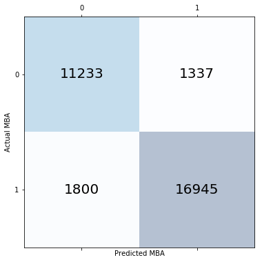

```python
import matplotlib.pyplot as plt
from sklearn.metrics import confusion_matrix
confmat = confusion_matrix(y_true=y_train, y_pred=y_pred)
fix, ax = plt.subplots(figsize=(6,8))
ax.matshow(confmat,cmap=plt.cm.Blues,alpha=0.3)
for i in range(confmat.shape[0]):
    for j in range(confmat.shape[1]):
        ax.text(x=j,y=i,s=confmat[i,j],
               va='center',ha='center',size=20)
plt.xlabel('Predicted MBA')
plt.ylabel('Actual MBA')
plt.show()
```

#### Precision/Recall Curve

```python
from sklearn.model_selection import cross_val_predict
y_scores = cross_val_predict(lr_clf,X_train,y_train,method='decision_function',n_jobs=1)
from sklearn.metrics import precision_recall_curve
y_train_bin = y_train
precisions,recalls,thresholds = precision_recall_curve(y_train_bin,y_scores)
```

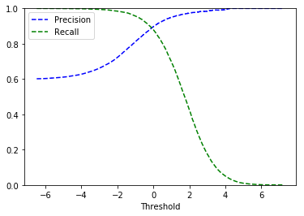

```python
def plot_precision_recall_vs_threshold(precisions,recalls,thresholds):
    plt.plot(thresholds,precisions[:-1],"b--",label="Precision")
    plt.plot(thresholds,recalls[:-1],"g--",label="Recall")
    plt.xlabel("Threshold")
    plt.legend(loc='upper left')
    plt.ylim([0,1])

plot_precision_recall_vs_threshold(precisions,recalls,thresholds)
plt.show()
```

#### ROC Curve

```python
from sklearn.metrics import roc_curve, auc, roc_auc_score
from sklearn.model_selection import cross_val_predict
# y_scores = cross_val_predict(lr_clf,X_train,y_train,cv=5)
# y_scores = cross_val_predict(lr_clf,X_train,y_train,cv=5,method='decision_function')
```

```python
# y_train_bin = np.where(y_train=="mba",1,0)
# y_scores_bin = np.where(y_scores=="mba",1,0)
fpr,tpr,thresholds = roc_curve(y_train_bin,y_scores,pos_label=1)
```

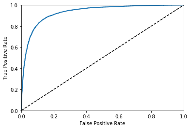

```python
def plot_roc_curve(fpr,tpr,label=None):
    plt.plot(fpr,tpr,linewidth=2,label=label)
    plt.plot([0,1],[0,1],'k--')
    plt.axis([0,1,0,1])
    plt.xlabel('False Positive Rate')
    plt.ylabel('True Positive Rate')
plot_roc_curve(fpr,tpr)
plt.show()
```

```python
roc_auc_score(y_train_bin,y_scores)
```

```
0.93179866792375066
```

## K Nearest Neighbors

**K Nearest Neighbors (KNN)** is a non-parametric algorithm. KNN has been called a **lazy** learning algorithm due to the fact that it does not learn a discriminative function from the training data, but instead memorizes the data. These non-parametric algorithms cannot be characterized by a fixed set of parameters like logistic regression, but instead are characterized as the dataset grows in size. An example of another non-parametric algorithm is random forests, which we will explore later. KNN belongs to a subset of non-parametric algorithms called **instance-based learners**.

The biggest advantage of non-parametric, memory-based approaches, is the classifier's ability to adapt well to new training data.

However, with non-parametric algorithms, computational complexity grows linearly with the size of the training data, leading to computationally expensive models. It is also worth noting that KNN is susceptable to underforming in high-dimensionality datasets.

KNN runs based on the following steps:

```
* Given a pre-selected number of K neighbors and specified distance metric:
    * Find the k nearest neighbors of the sample for classification
    * Assign the class label via majority vote.
```

**Hyperparameters explored:**

[output not shown]

```python
#GRID SEARCH WIP
```

```python
from sklearn.neighbors import KNeighborsClassifier
from sklearn.pipeline import Pipeline

# parameters = {'clf__weights':['uniform','distance'],
#               'clf__n_neighbors': [5, 10, 20, 30, 40, 50, 60, 70, 80, 90, 100]}


# knn_clf = GridSearchCV(knn_clf, param_grid=parameters, scoring='roc_auc',n_jobs=1,cv=10,verbose=10)

# knn_clf.best_params_
# {'clf__n_neighbors': 30, 'clf__weights': 'distance'}


knn_clf = Pipeline([('vect', CountVectorizer()),
                      ('tfidf', TfidfTransformer()),
                      ('clf', KNeighborsClassifier(n_neighbors=30,
                                                  weights='distance'))
])

knn_clf.fit(X_train, y_train)
```

```
Pipeline(steps=[('vect', CountVectorizer(analyzer='word', binary=False, decode_error='strict',
        dtype=<class 'numpy.int64'>, encoding='utf-8', input='content',
        lowercase=True, max_df=1.0, max_features=None, min_df=1,
        ngram_range=(1, 1), preprocessor=None, stop_words=None,
        strip...ski',
           metric_params=None, n_jobs=1, n_neighbors=30, p=2,
           weights='distance'))])
```

```python
knn_clf.fit(X_train,y_train)
y_pred = knn_clf.predict(X_train)
```

```python
print('Train Accuracy: %.3f' % knn_clf.score(X_train, y_train))
```

```
Train Accuracy: 0.991
```

#### Performance Metrics

```python
from sklearn import metrics
print(metrics.classification_report(y_test,y_pred))
```

[output not shown]

#### Confusion Matrix

[figure not shown]

```python
from sklearn.metrics import confusion_matrix
confmat = confusion_matrix(y_true=y_test, y_pred=y_pred)
fix, ax = plt.subplots(figsize=(6,8))
ax.matshow(confmat,cmap=plt.cm.Blues,alpha=0.3)
for i in range(confmat.shape[0]):
    for j in range(confmat.shape[1]):
        ax.text(x=j,y=i,s=confmat[i,j],
               va='center',ha='center',size=20)
plt.xlabel('Predicted MBA')
plt.ylabel('Actual MBA')
plt.show()
```

#### Precision/Recall Curve

```python
y_probas_knn = cross_val_predict(knn_clf,X_train,y_train,cv=5,method='predict_proba')
y_scores_knn = y_probas_knn[:,1]
from sklearn.metrics import precision_recall_curve
y_train_bin = np.where(y_train=="mba",1,0)
precisions,recalls,thresholds = precision_recall_curve(y_train_bin,y_scores_knn)
```

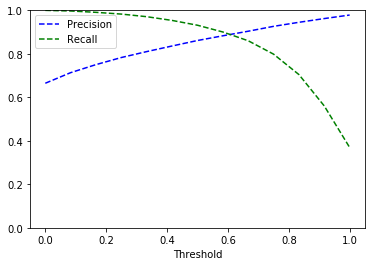

```python
def plot_precision_recall_vs_threshold(precisions,recalls,thresholds):
    plt.plot(thresholds,precisions[:-1],"b--",label="Precision")
    plt.plot(thresholds,recalls[:-1],"g--",label="Recall")
    plt.xlabel("Threshold")
    plt.legend(loc='upper left')
    plt.ylim([0,1])

plot_precision_recall_vs_threshold(precisions,recalls,thresholds)
plt.show()
```

#### ROC Curve

```python
from sklearn.metrics import roc_curve, auc
```

```python
fpr,tpr,thresholds = roc_curve(y_train_bin,y_scores_knn,pos_label=1)
```

```python
def plot_roc_curve(fpr,tpr,label=None):
    plt.plot(fpr,tpr,linewidth=2,label=label)
    plt.plot([0,1],[0,1],'k--')
    plt.axis([0,1,0,1])
    plt.xlabel('False Positive Rate')
    plt.ylabel('True Positive Rate')
```

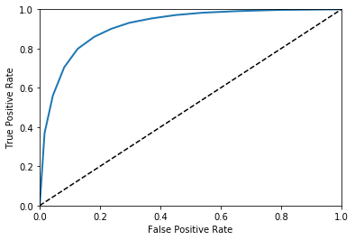

```python
plot_roc_curve(fpr,tpr)
plt.show()
```

```python
roc_auc_score(y_train_bin,y_scores_knn)
```

```
0.91420927120608586
```

## Naive Bayes

Naive Bayes assume that the value of a given feature is independent of the value of any other feature.

https://en.wikipedia.org/wiki/Naive_Bayes_classifier

**Hyperparameters explored:**

```
* Alpha (alpha):
```

```python
import sklearn         #added this line
from sklearn.feature_extraction.text import CountVectorizer
from sklearn.feature_extraction.text import TfidfTransformer
```

```python
from sklearn.naive_bayes import MultinomialNB
from sklearn.pipeline import Pipeline
nb_clf = Pipeline([('vect', CountVectorizer()),
                      ('tfidf', TfidfTransformer()),
                      ('clf', MultinomialNB())
])

parameters = {'clf__alpha': [0.0001,0.001, 0.01, 0.1,1]}

nb_clf = GridSearchCV(nb_clf, param_grid=parameters, scoring='roc_auc',n_jobs=-1,cv=10,verbose=True)
```

```python
nb_clf.fit(X_train, y_train)
print('Train Accuracy: %.3f' % nb_clf.score(X_train, y_train))
y_pred = nb_clf.predict(X_train)
```

```
Fitting 10 folds for each of 5 candidates, totalling 50 fits
```

```
[Parallel(n_jobs=-1)]: Done  26 tasks      | elapsed:    9.8s
[Parallel(n_jobs=-1)]: Done  50 out of  50 | elapsed:   14.9s finished
```

```
Train Accuracy: 0.954
```

```python
nb_clf.best_params_
```

```
{'clf__alpha': 0.1}
```

```python
#nb_clf.best_params_
#{'clf__alpha': 0.1}
```

```python
nb_clf.best_estimator_
```

```
Pipeline(steps=[('vect', CountVectorizer(analyzer='word', binary=False, decode_error='strict',
        dtype=<class 'numpy.int64'>, encoding='utf-8', input='content',
        lowercase=True, max_df=1.0, max_features=None, min_df=1,
        ngram_range=(1, 1), preprocessor=None, stop_words=None,
        strip...inear_tf=False, use_idf=True)), ('clf', MultinomialNB(alpha=0.1, class_prior=None, fit_prior=True))])
```

#### Performance Metrics

```python
from sklearn import metrics
print(metrics.classification_report(y_train,y_pred))
```

[output not shown]

#### Confusion Matrix

[figure not shown]

```python
from sklearn.metrics import confusion_matrix
confmat = confusion_matrix(y_true=y_train, y_pred=y_pred)
fix, ax = plt.subplots(figsize=(6,8))
ax.matshow(confmat,cmap=plt.cm.Blues,alpha=0.3)
for i in range(confmat.shape[0]):
    for j in range(confmat.shape[1]):
        ax.text(x=j,y=i,s=confmat[i,j],
               va='center',ha='center',size=20)
plt.xlabel('Predicted Label')
plt.ylabel('True Label')
plt.show()
```

#### Precision/Recall Curve

```python
y_probas_nb = cross_val_predict(nb_clf,X_train,y_train,cv=10,method='predict_proba')
# y_probas_forest = cross_val_predict(forest_clf,X_train,y_train,cv=5,method="predict_proba")
y_scores_nb = y_probas_nb[:,1]
from sklearn.metrics import precision_recall_curve
# y_train_bin = np.where(y_train=="mba",1,0)
# precisions,recalls,thresholds = precision_recall_curve(y_train_bin,y_scores)
```

[output not shown]

```
[Parallel(n_jobs=-1)]: Done  26 tasks      | elapsed:    9.0s
[Parallel(n_jobs=-1)]: Done  60 out of  60 | elapsed:   15.9s finished
```

[output not shown]

```
[Parallel(n_jobs=-1)]: Done  26 tasks      | elapsed:    9.1s
[Parallel(n_jobs=-1)]: Done  60 out of  60 | elapsed:   16.1s finished
```

[output not shown]

```
[Parallel(n_jobs=-1)]: Done  26 tasks      | elapsed:    9.2s
[Parallel(n_jobs=-1)]: Done  60 out of  60 | elapsed:   16.0s finished
```

[output not shown]

```
[Parallel(n_jobs=-1)]: Done  26 tasks      | elapsed:    9.2s
[Parallel(n_jobs=-1)]: Done  60 out of  60 | elapsed:   15.6s finished
```

[output not shown]

```
[Parallel(n_jobs=-1)]: Done  26 tasks      | elapsed:    9.1s
[Parallel(n_jobs=-1)]: Done  60 out of  60 | elapsed:   15.7s finished
```

[output not shown]

```
[Parallel(n_jobs=-1)]: Done  26 tasks      | elapsed:    9.0s
[Parallel(n_jobs=-1)]: Done  60 out of  60 | elapsed:   15.7s finished
```

[output not shown]

```
[Parallel(n_jobs=-1)]: Done  26 tasks      | elapsed:    9.0s
[Parallel(n_jobs=-1)]: Done  60 out of  60 | elapsed:   15.6s finished
```

[output not shown]

```
[Parallel(n_jobs=-1)]: Done  26 tasks      | elapsed:    9.0s
[Parallel(n_jobs=-1)]: Done  60 out of  60 | elapsed:   15.6s finished
```

[output not shown]

```
[Parallel(n_jobs=-1)]: Done  26 tasks      | elapsed:    9.1s
[Parallel(n_jobs=-1)]: Done  60 out of  60 | elapsed:   15.5s finished
```

[output not shown]

```
[Parallel(n_jobs=-1)]: Done  26 tasks      | elapsed:    9.1s
[Parallel(n_jobs=-1)]: Done  60 out of  60 | elapsed:   15.8s finished
```

```python
y_train_bin = y_train
# y_train_bin = np.where(y_train=="mba",1,0)
```

```python
precisions,recalls,thresholds = precision_recall_curve(y_train_bin,y_scores_nb)
```

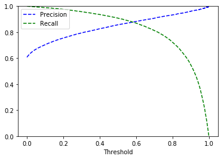

```python
def plot_precision_recall_vs_threshold(precisions,recalls,thresholds):
    plt.plot(thresholds,precisions[:-1],"b--",label="Precision")
    plt.plot(thresholds,recalls[:-1],"g--",label="Recall")
    plt.xlabel("Threshold")
    plt.legend(loc='upper left')
    plt.ylim([0,1])

plot_precision_recall_vs_threshold(precisions,recalls,thresholds)
plt.show()
```

#### ROC Curve

```python
from sklearn.metrics import roc_curve, auc, roc_auc_score
from sklearn.model_selection import cross_val_predict
# y_scores = cross_val_predict(lr_clf,X_train,y_train,cv=5)
# y_scores = cross_val_predict(nb_clf,X_train,y_train,cv=5,method='decision_function')
```

```python
# y_train_bin = np.where(y_train=="mba",1,0)
# y_scores_bin = np.where(y_scores=="mba",1,0)
fpr,tpr,thresholds = roc_curve(y_train_bin,y_scores_nb,pos_label=1)
```

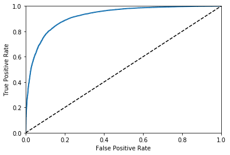

```python
def plot_roc_curve(fpr,tpr,label=None):
    plt.plot(fpr,tpr,linewidth=2,label=label)
    plt.plot([0,1],[0,1],'k--')
    plt.axis([0,1,0,1])
    plt.xlabel('False Positive Rate')
    plt.ylabel('True Positive Rate')
plot_roc_curve(fpr,tpr)
plt.show()
```

```python
roc_auc_score(y_train_bin,y_scores_nb)
```

```
0.92091068075165561
```

## Support Vector Machine

**Support Vector Machine (SVM)** is an algorithm which can perform both linear and nonlinear classification. SVM seeks to find the widest possible margin or distance between the decision boundary of the distinct classes and the training samples themselves. The balancing act in SVM is to keep the gulf between the classes as large as possible while simeltaneously limiting the number of samples that end up in the gulf. This process is called **soft margin classification**. Decision boundaries with large margins tend to generalize better while those with small margins are more prone to overfitting.

Trained SVMs produce **support vectors** which can be thought of as an instance which is located within the gulf mentioned above. These support vectors influence the decision boundary. Additionally, model predictions are made using only these support vectors and not the entire training set.

#### Cost Penalization

Similar to how we implemented regularization with logistic regression, we can control the level of cost penalization with SVM, which in turn controls the width of the margin gulf. This has the same effect of controlling the bias-variance tradeoff.

Use kernels on non-linear datasets.

**Hyperparameters explored:**

```
* Pemalty for Misclassification (C):
    * A smaller C value leads to a wider gulf but more margin violations.
    * A higher C value leads to a more narrow gulf with fewer margin volations.
* Kernel:
    * rbf:
    * linear: The classes are linearly separable.
    * poly:
```

```python
from sklearn.model_selection import GridSearchCV
# from sklearn.svm import LinearSVC
from sklearn.svm import SVC
from sklearn.pipeline import Pipeline
```

```python
svm_clf = Pipeline([('vect', CountVectorizer()),
                      ('tfidf', TfidfTransformer()),
                      ('clf', SVC(probability=True,class_weight="balanced")),
])

parameters = {'clf__C': [0.001, 0.01, 0.1, 1, 10, 100, 1000],
             'clf__kernel': ["rbf","linear","poly"]}

svm_clf = GridSearchCV(svm_clf, param_grid=parameters, scoring='roc_auc',n_jobs=-1,cv=10,verbose=True)

svm_clf.fit(X_train, y_train)
print('Test Accuracy: %.3f' % svm_clf.score(X_train, y_train))
y_pred = svm_clf.predict(X_train)
```

```
Fitting 10 folds for each of 21 candidates, totalling 210 fits
```

```
[Parallel(n_jobs=-1)]: Done  26 tasks      | elapsed: 136.3min
[Parallel(n_jobs=-1)]: Done 176 tasks      | elapsed: 737.3min
[Parallel(n_jobs=-1)]: Done 210 out of 210 | elapsed: 900.6min finished
```

```
Test Accuracy: 0.965
```

```python
svm_clf.best_params_
```

```
{'clf__C': 1, 'clf__kernel': 'linear'}
```

```python
#svm_clf.best_params_
#{'clf__C': 1, 'clf__kernel': 'linear'}
```

```python
svm_clf.best_estimator_
```

```
Pipeline(steps=[('vect', CountVectorizer(analyzer='word', binary=False, decode_error='strict',
        dtype=<class 'numpy.int64'>, encoding='utf-8', input='content',
        lowercase=True, max_df=1.0, max_features=None, min_df=1,
        ngram_range=(1, 1), preprocessor=None, stop_words=None,
        strip...',
  max_iter=-1, probability=True, random_state=None, shrinking=True,
  tol=0.001, verbose=False))])
```

#### Performance Metrics

```python
from sklearn import metrics
print(metrics.classification_report(y_test,y_pred,
                       target_names=svm_clf.classes_))
```

[output not shown]

#### Confusion Matrix

[figure not shown]

```python
import matplotlib.pyplot as plt
from sklearn.metrics import confusion_matrix
confmat = confusion_matrix(y_true=y_test, y_pred=y_pred)
fix, ax = plt.subplots(figsize=(6,8))
ax.matshow(confmat,cmap=plt.cm.Blues,alpha=0.3)
for i in range(confmat.shape[0]):
    for j in range(confmat.shape[1]):
        ax.text(x=j,y=i,s=confmat[i,j],
               va='center',ha='center',size=20)
plt.xlabel('Predicted MBA')
plt.ylabel('Actual MBA')
plt.show()
```

#### Precision/Recall Curve

```python
y_scores = cross_val_predict(svm_clf,X_train,y_train,cv=5,method='decision_function')
from sklearn.metrics import precision_recall_curve
y_train_bin = np.where(y_train=="mba",1,0)
precisions,recalls,thresholds = precision_recall_curve(y_train_bin,y_scores)
```

[output not shown]

[output cut: 47 more lines]

[output not shown]

```python
def plot_precision_recall_vs_threshold(precisions,recalls,thresholds):
    plt.plot(thresholds,precisions[:-1],"b--",label="Precision")
    plt.plot(thresholds,recalls[:-1],"g--",label="Recall")
    plt.xlabel("Threshold")
    plt.legend(loc='upper left')
    plt.ylim([0,1])

plot_precision_recall_vs_threshold(precisions,recalls,thresholds)
plt.show()
```

[output not shown]

#### ROC Curve

```python
from sklearn.metrics import roc_curve, auc, roc_auc_score
from sklearn.model_selection import cross_val_predict
# y_scores = cross_val_predict(lr_clf,X_train,y_train,cv=5)
y_scores = cross_val_predict(svm_clf,X_train,y_train,cv=5,method='decision_function')
```

```python
y_train_bin = np.where(y_train=="mba",1,0)
# y_scores_bin = np.where(y_scores=="mba",1,0)
fpr,tpr,thresholds = roc_curve(y_train_bin,y_scores,pos_label=1)
```

```python
def plot_roc_curve(fpr,tpr,label=None):
    plt.plot(fpr,tpr,linewidth=2,label=label)
    plt.plot([0,1],[0,1],'k--')
    plt.axis([0,1,0,1])
    plt.xlabel('False Positive Rate')
    plt.ylabel('True Positive Rate')
plot_roc_curve(fpr,tpr)
plt.show()
```

[output not shown]

```python
roc_auc_score(y_train_bin,y_scores)
```

[output not shown]

```python
# pipe_svc = Pipeline([('vect', CountVectorizer()),
#                       ('tfidf', TfidfTransformer()),
#                      ('clf',SVC(random_state=1))])

# param_range = [0.0001, 0.001, 0.01, 0.1, 1.0, 10.0, 100.0, 1000.0]

# param_grid = [{'clf__C': param_range,
#                'clf__kernel': ['linear']},
#                  {'clf__C': param_range,
#                   'clf__gamma': param_range,
#                   'clf__kernel': ['rbf']}]

# gs = GridSearchCV(estimator=pipe_svc,
#                   param_grid=param_grid,
#                   scoring='accuracy',
#                   cv=10,
#                   n_jobs=-1)

# gs = gs.fit(X_train, y_train)
# print(gs.best_score_)
# print(gs.best_params_)
```

```python
# clf = gs.best_estimator_
# clf.fit(X_train, y_train)
# print('Test accuracy: %.3f' % clf.score(X_test, y_test))
```

## Stochastic Gradient Descent

**Hyperparameters explored:**

[output not shown]

```python
from sklearn.linear_model import SGDClassifier
sgd_clf = Pipeline([('vect', CountVectorizer()),
                      ('tfidf', TfidfTransformer()),
                      ('clf', SGDClassifier(class_weight='balanced',
                                            n_jobs=-1,random_state=1))])

parameters = {'clf__alpha': [0.0001,0.001, 0.01, 0.1, 1],
             'clf__penalty': ['l2','l1','elasticnet'],
             'clf__loss': ['hinge', 'log']
}

sgd_clf = GridSearchCV(sgd_clf, param_grid=parameters, scoring='roc_auc',n_jobs=-1,cv=10,verbose=10)
```

```python
sgd_clf.fit(X_train, y_train)
print('Train Accuracy: %.3f' % sgd_clf.score(X_train, y_train))
```

[output not shown]

```
[Parallel(n_jobs=-1)]: Done   1 tasks      | elapsed:    3.3s
```

[output not shown]

```
[Parallel(n_jobs=-1)]: Done   8 tasks      | elapsed:    3.9s
```

[output not shown]

```
[Parallel(n_jobs=-1)]: Done  17 tasks      | elapsed:    7.4s
```

[output not shown]

```
[Parallel(n_jobs=-1)]: Done  26 tasks      | elapsed:   10.5s
```

[output not shown]

```
[Parallel(n_jobs=-1)]: Done  37 tasks      | elapsed:   13.9s
```

[output not shown]

```
[Parallel(n_jobs=-1)]: Done  48 tasks      | elapsed:   15.6s
```

[output not shown]

```
[Parallel(n_jobs=-1)]: Done  61 tasks      | elapsed:   20.8s
```

[output not shown]

```
[Parallel(n_jobs=-1)]: Done  74 tasks      | elapsed:   24.8s
```

[output not shown]

```
[Parallel(n_jobs=-1)]: Done  89 tasks      | elapsed:   28.8s
```

[output not shown]

```
[Parallel(n_jobs=-1)]: Done 104 tasks      | elapsed:   33.0s
```

[output not shown]

```
[Parallel(n_jobs=-1)]: Done 121 tasks      | elapsed:   38.8s
```

[output not shown]

```
[Parallel(n_jobs=-1)]: Done 138 tasks      | elapsed:   43.5s
```

[output not shown]

```
[Parallel(n_jobs=-1)]: Done 157 tasks      | elapsed:   49.0s
```

[output not shown]

```
[Parallel(n_jobs=-1)]: Done 176 tasks      | elapsed:   54.4s
```

[output not shown]

```
[Parallel(n_jobs=-1)]: Done 197 tasks      | elapsed:  1.0min
```

[output not shown]

```
[Parallel(n_jobs=-1)]: Done 218 tasks      | elapsed:  1.1min
```

[output not shown]

```
[Parallel(n_jobs=-1)]: Done 241 tasks      | elapsed:  1.2min
```

[output not shown]

```
[Parallel(n_jobs=-1)]: Done 264 tasks      | elapsed:  1.3min
```

[output not shown]

```
[Parallel(n_jobs=-1)]: Done 300 out of 300 | elapsed:  1.5min finished
```

```
Train Accuracy: 0.952
```

```python
sgd_clf.best_estimator_
```

```
Pipeline(steps=[('vect', CountVectorizer(analyzer='word', binary=False, decode_error='strict',
        dtype=<class 'numpy.int64'>, encoding='utf-8', input='content',
        lowercase=True, max_df=1.0, max_features=None, min_df=1,
        ngram_range=(1, 1), preprocessor=None, stop_words=None,
        strip...      penalty='l2', power_t=0.5, random_state=1, shuffle=True, verbose=0,
       warm_start=False))])
```

```python
sgd_clf.best_params_
```

```
{'clf__alpha': 0.0001, 'clf__loss': 'hinge', 'clf__penalty': 'l2'}
```

```python
# sgd_clf.best_params_
# {'clf__alpha': 0.0001, 'clf__loss': 'hinge', 'clf__penalty': 'l2'}
```

```python
# sgd_clf.fit(X_train, y_train)
```

```python
# print('Test Accuracy: %.3f' % sgd_clf.score(X_test, y_test))
```

#### Performance Metrics

```python
from sklearn import metrics
y_train_pred = sgd_clf.predict(X_train)
y_pred = sgd_clf.predict(X_test)
print(metrics.classification_report(y_test,y_pred,
                       target_names=sgd_clf.classes_))
```

```
              precision    recall  f1-score   support

data_science       0.91      0.65      0.76      1861
         mba       0.89      0.98      0.93      5276

 avg / total       0.89      0.89      0.88      7137
```

#### Confusion Matrix

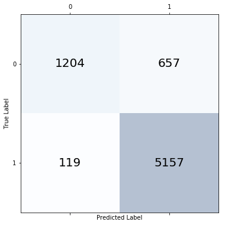

```python
from sklearn.metrics import confusion_matrix
confmat = confusion_matrix(y_true=y_test, y_pred=y_pred)
fix, ax = plt.subplots(figsize=(6,8))
ax.matshow(confmat,cmap=plt.cm.Blues,alpha=0.3)
for i in range(confmat.shape[0]):
    for j in range(confmat.shape[1]):
        ax.text(x=j,y=i,s=confmat[i,j],
               va='center',ha='center',size=20)
plt.xlabel('Predicted Label')
plt.ylabel('True Label')
plt.show()
```

#### Precision-Recall Curve

```python
y_scores = cross_val_predict(sgd_clf,X_train,y_train,cv=5,method='decision_function')
```

```python
from sklearn.metrics import precision_recall_curve
y_train_bin = np.where(y_train=="mba",1,0)
precisions,recalls,thresholds = precision_recall_curve(y_train_bin,y_scores)
```

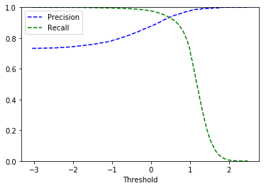

```python
def plot_precision_recall_vs_threshold(precisions,recalls,thresholds):
    plt.plot(thresholds,precisions[:-1],"b--",label="Precision")
    plt.plot(thresholds,recalls[:-1],"g--",label="Recall")
    plt.xlabel("Threshold")
    plt.legend(loc='upper left')
    plt.ylim([0,1])

plot_precision_recall_vs_threshold(precisions,recalls,thresholds)
plt.show()
```

#### ROC Curve

```python
from sklearn.metrics import roc_curve,roc_auc_score
fpr,tpr,thresholds = roc_curve(y_train_bin,y_scores)
```

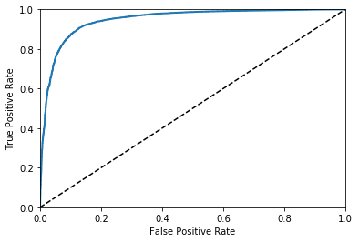

```python
plot_roc_curve(fpr,tpr)
plt.show()
```

```python
roc_auc_score(y_train_bin,y_scores)
```

```
0.94776300753975118
```

## Random Forests

Random forests fall under the 'ensemble' family of machine learning classifiers. The model takes a random sample of observations as well as a random subset of features during training which it uses to build decision trees.

**Hyperparameters explored**:

```
* Tree size (n_estimators):
    * This parameter specifies the number of trees to be fitted in order to take the aggregate decision (max vote or average prediction).
    * Increasing the tree size will generally improve model accuracy but slow completion time.
* Max Features (max_features):
    * This parameter specifies the maximum number of features the model uses in fitting individual trees.
    * Increasing the max features will typically improve model performance as a higher number of features are being used to fit at each decision node, however doing so will lower the diversity of the tree (and lead to overfitting).
    * The more features used, the longer the model will take to train.
    * Parameter Options include:
        * Use all features (Auto/None)
        * Use the square root of the number of features (sqrt)
        * Use the base log number of features (log2)
        * Use a specified percent of the number of features (0.X)
* Minimum sample leaf (min_sample_leaf):
    * This parameter limits the minimum leaf (or end node) size of the decision tree.
    * Typically larger leaves capture less noise in the training data.
* Decision criterion (criterion):
    * This parameter is the method by which predictions are made by our classifier.
        * Gini Index:
            * A measure of node purity.  Smaller values indicate node purity, larger values indicate node impurity.
            * For a split to take place, the Gini index for a child node should be less than that of the parent node.
        * Entropy:
            * A measure of node *impurity.* This value ranges between 0 and 1, where 0.5 indicates maximum impurity and the highest uncertainty of making a decision.
```

```python
from sklearn.ensemble import RandomForestClassifier
# forest_clf = RandomForestClassifier(random_state=42)
forest_clf = Pipeline([('vect', CountVectorizer()),
                      ('tfidf', TfidfTransformer()),
                      ('clf', RandomForestClassifier(class_weight='balanced',
                                                     random_state=1))])


parameters = {'clf__n_estimators': [10,50,100,500,1000],
             'clf__max_features': ["auto","sqrt","log2"],
             'clf__min_samples_leaf': [50,100,200,500],
             'clf__criterion': ['gini','entropy']}

forest_clf = GridSearchCV(forest_clf, param_grid=parameters, scoring='roc_auc',n_jobs=-1,cv=10,verbose=10)
```

```python
forest_clf.fit(X_train, y_train)
```

[output not shown]

```
[Parallel(n_jobs=-1)]: Done   1 tasks      | elapsed:    3.6s
```

[output not shown]

```
[Parallel(n_jobs=-1)]: Done   8 tasks      | elapsed:    4.2s
```

[output not shown]

```
[Parallel(n_jobs=-1)]: Done  17 tasks      | elapsed:    9.4s
```

[output not shown]

```
[Parallel(n_jobs=-1)]: Done  26 tasks      | elapsed:   16.0s
```

[output not shown]

```
[Parallel(n_jobs=-1)]: Done  37 tasks      | elapsed:   36.8s
```

[output not shown]

```
[Parallel(n_jobs=-1)]: Done  48 tasks      | elapsed:   52.6s
```

[output not shown]

```
[Parallel(n_jobs=-1)]: Done  61 tasks      | elapsed:  1.1min
```

[output not shown]

```
[Parallel(n_jobs=-1)]: Done  74 tasks      | elapsed:  1.3min
```

[output not shown]

```
[Parallel(n_jobs=-1)]: Done  89 tasks      | elapsed:  1.5min
```

[output not shown]

```
[Parallel(n_jobs=-1)]: Done 104 tasks      | elapsed:  1.9min
```

[output not shown]

```
[Parallel(n_jobs=-1)]: Done 121 tasks      | elapsed:  2.1min
```

[output not shown]

```
[Parallel(n_jobs=-1)]: Done 138 tasks      | elapsed:  2.3min
```

[output not shown]

```
[Parallel(n_jobs=-1)]: Done 157 tasks      | elapsed:  2.6min
```

[output not shown]

```
[Parallel(n_jobs=-1)]: Done 176 tasks      | elapsed:  2.8min
```

[output not shown]

```
[Parallel(n_jobs=-1)]: Done 197 tasks      | elapsed:  3.1min
```

[output not shown]

```
[Parallel(n_jobs=-1)]: Done 218 tasks      | elapsed:  3.3min
```

[output not shown]

```
[Parallel(n_jobs=-1)]: Done 241 tasks      | elapsed:  3.8min
```

[output not shown]

```
[Parallel(n_jobs=-1)]: Done 264 tasks      | elapsed:  4.3min
```

[output not shown]

```
[Parallel(n_jobs=-1)]: Done 289 tasks      | elapsed:  4.6min
```

[output not shown]

```
[Parallel(n_jobs=-1)]: Done 314 tasks      | elapsed:  5.1min
```

[output not shown]

[output cut: 18 more lines]

```
[Parallel(n_jobs=-1)]: Done 341 tasks      | elapsed:  5.5min
```

[output not shown]

[output cut: 18 more lines]

```
[Parallel(n_jobs=-1)]: Done 368 tasks      | elapsed:  5.8min
```

[output not shown]

[output cut: 20 more lines]

```
[Parallel(n_jobs=-1)]: Done 397 tasks      | elapsed:  6.2min
```

[output not shown]

[output cut: 19 more lines]

```
[Parallel(n_jobs=-1)]: Done 426 tasks      | elapsed:  6.4min
```

[output not shown]

[output cut: 21 more lines]

```
[Parallel(n_jobs=-1)]: Done 457 tasks      | elapsed:  6.8min
```

[output not shown]

[output cut: 21 more lines]

```
[Parallel(n_jobs=-1)]: Done 488 tasks      | elapsed:  7.1min
```

[output not shown]

[output cut: 11 more lines]

[output not shown]

```
[Parallel(n_jobs=-1)]: Done 521 tasks      | elapsed:  7.5min
```

[output not shown]

[output cut: 11 more lines]

[output not shown]

```
[Parallel(n_jobs=-1)]: Done 554 tasks      | elapsed:  7.9min
```

[output not shown]

[output cut: 15 more lines]

[output not shown]

```
[Parallel(n_jobs=-1)]: Done 589 tasks      | elapsed:  8.2min
```

[output not shown]

[output cut: 15 more lines]

[output not shown]

```
[Parallel(n_jobs=-1)]: Done 624 tasks      | elapsed:  8.6min
```

[output not shown]

[output cut: 19 more lines]

[output not shown]

```
[Parallel(n_jobs=-1)]: Done 661 tasks      | elapsed:  9.6min
```

[output not shown]

[output cut: 19 more lines]

[output not shown]

```
[Parallel(n_jobs=-1)]: Done 698 tasks      | elapsed: 10.3min
```

[output not shown]

[output cut: 23 more lines]

[output not shown]

```
[Parallel(n_jobs=-1)]: Done 737 tasks      | elapsed: 10.9min
```

[output not shown]

[output cut: 26 more lines]

[output not shown]

```
[Parallel(n_jobs=-1)]: Done 776 tasks      | elapsed: 11.3min
```

[output not shown]

[output cut: 25 more lines]

[output not shown]

```
[Parallel(n_jobs=-1)]: Done 817 tasks      | elapsed: 11.9min
```

[output not shown]

[output cut: 28 more lines]

[output not shown]

```
[Parallel(n_jobs=-1)]: Done 858 tasks      | elapsed: 12.9min
```

[output not shown]

[output cut: 29 more lines]

[output not shown]

```
[Parallel(n_jobs=-1)]: Done 901 tasks      | elapsed: 13.7min
```

[output not shown]

[output cut: 31 more lines]

[output not shown]

```
[Parallel(n_jobs=-1)]: Done 944 tasks      | elapsed: 14.4min
```

[output not shown]

[output cut: 35 more lines]

[output not shown]

```
[Parallel(n_jobs=-1)]: Done 989 tasks      | elapsed: 14.9min
```

[output not shown]

[output cut: 36 more lines]

[output not shown]

```
[Parallel(n_jobs=-1)]: Done 1034 tasks      | elapsed: 15.4min
```

[output not shown]

[output cut: 40 more lines]

[output not shown]

```
[Parallel(n_jobs=-1)]: Done 1081 tasks      | elapsed: 15.9min
```

[output not shown]

[output cut: 39 more lines]

[output not shown]